# Rekruttering til uddannelse: Analyse

- Show All Code
- Hide All Code
- View Source

Author

Christian Heide

Published

January 13, 2025

Dette dokument ineholder hovedanalysen til projektet “Rekruttering til uddannelse”. Data er bearbejdet i et seperat script, så formålet med dette dokument er alene at vise hvordan analysen samt figurer, tabeller mm. er produceret. For gennemsigtighedens skyld har jeg dog inkluderet data-transformationer i dette script

```r
# Libraries
library(tidyverse)
library(gsynth)
library(panelView)
library(xtable)
library(patchwork)
library(stargazer)

# Data
df <- readRDS("data/processed/ansøgninger_1997-2024.RDS")

# Functions
lm_impute <- function(df, missing_var, rhs, education) { # To impute missing values

  edu_df <- df |>
    filter(uddannelse == education)

  # Indices of rows with missing values
  missing_rows <- which(is.na(df[[missing_var]]) & df$uddannelse == education)

  if (nrow(edu_df) > length(missing_rows)) {

      # Linear model
    temp_model <- lm(
      formula = as.formula(paste(missing_var, "~", rhs)),
      data = edu_df,
      na.action = na.exclude
      )

    # Using model to impute missing values
    df[[missing_var]][missing_rows] <- predict(temp_model, df[missing_rows,])

  }

  return(df)
}
```

# 1 Transformationer

Til brug for min primære uafhængige variabel transformerer jeg førsteprioritetsansøgninger, så: 1) Sygeplejerskeuddannelsen opdeles i kvote 1 og kvote 2 ansøgninger, og 2) Læreruddannelsen alene inkluderer ansøgninger med et karaktergennemsnit over 7. Jeg transformerer naturligvis også kontrolenhederne, så jeg sammenligner æbler med æbler :)

## 1.1 Transformation for sygeplejerskeuddannelsen

```r
# Opdeler sygeplejerskeuddannelsen i kvote 1 og 2
# Ekstrapolerer først trenden i andel kvote 2 ansøgere blandt sygeplejersker og
# regner antal kvote 2 ud
df_sygeplejerske <- df

# Lineær imputing
for (u in unique(df_sygeplejerske$uddannelse)) {
  df_sygeplejerske <- df_sygeplejerske |>
    lm_impute(missing_var = "andel_kvote2_prio1", rhs = "år", education = u) |>
    lm_impute(missing_var = "andel_kvote2_total", rhs = "år", education = u)
}

df_sygeplejerske <- df_sygeplejerske |>
  mutate(
    ansøgninger_prio1_kvote2 = if_else(
      år < 2009,
      ansøgninger_prio1 * andel_kvote2_prio1,
      ansøgninger_prio1_kvote2),
    ansøgninger_total_kvote2 = if_else(
      år < 2009,
      ansøgninger_total * andel_kvote2_total,
      ansøgninger_total_kvote2))

# Bruger dette til at opdele på kvote 1 og 2
df_sygeplejerske <- df_sygeplejerske |>

  # Kvote 1 ansøgninger for sygeplejersker
  mutate(
    ansøgninger_main = ansøgninger_prio1 - ansøgninger_prio1_kvote2,
    ansøgninger_robust_total = ansøgninger_total - ansøgninger_total_kvote2,
    uddannelse = if_else(
      treatment == "Sygeplejerskestrejke",
      "Sygeplejerske (kvote 1)",
      uddannelse))

# Kvote 2 ansøgninger for sygeplejersker
df_sygeplejerske_k2 <- df

# Lineær imputing
for (u in unique(df_sygeplejerske_k2$uddannelse)) {
  df_sygeplejerske_k2 <- df_sygeplejerske_k2 |>
    lm_impute(missing_var = "andel_kvote2_prio1", rhs = "år", education = u) |>
    lm_impute(missing_var = "andel_kvote2_total", rhs = "år", education = u)
}

df_sygeplejerske_k2 <- df_sygeplejerske_k2 |>
  mutate(
    ansøgninger_prio1_kvote2 = if_else(
      år < 2009,
      ansøgninger_prio1 * andel_kvote2_prio1,
      ansøgninger_prio1_kvote2),
    ansøgninger_total_kvote2 = if_else(
      år < 2009,
      ansøgninger_total * andel_kvote2_total,
      ansøgninger_total_kvote2))

df_sygeplejerske_k2 <- df_sygeplejerske_k2 |>
  mutate(
    ansøgninger_main = ansøgninger_prio1_kvote2,
    ansøgninger_robust_total = ansøgninger_total_kvote2,
    uddannelse = if_else(
      treatment == "Sygeplejerskestrejke",
      "Sygeplejerske (kvote 2)",
      uddannelse))
```

## 1.2 Transformation for læreruddannelsen

```r
# Begræns læreruddannelsen til dem med at karaktergennemsnit på mindst 7.
# Imputer karaktergennemsnittet for 2009 for årene før

df_lærer <- df |>
  group_by(uddannelse) |>
  mutate(
    grade_2009 = ifelse(any(år == 2010), karakter[år == 2009], NA),
    karakter = ifelse(år < 2009 & is.na(karakter), grade_2009, karakter)
  ) |>
  select(-grade_2009) |>
  ungroup()

# Beregner andel med karaktergennemsnit over 7
#df_lærer$andel_over7 <- with(df_lærer, (1 - pnorm(7, mean = karakter, sd = 2)))
# Bruger weibul-fordeling. Nedenstående shape-parameter reproducerer den faktiske andel 2021. Ideen er at fordelingen skal være lettere højreskæv,
# fordi det er de optagne, og så må man formode at det er ansøgerne som minimum
# til samme grad. Har kun tal for 2021 at validere mod.
shape <-  2.2
df_lærer$andel_over7 <- with(df_lærer, (1 - pweibull(7, shape = shape, scale = (karakter) / gamma(1 + 1 / shape))))

# Alternativ weibul-fordeling
#shape <- 1.8
#df_lærer$andel_over7 <- with(df_lærer, (1 - pweibull(7, shape = shape, scale = karakter)))

# Transformerer herefter outcome for læreruddannelsen til at være antal med
# snit over 7
df_lærer <- df_lærer |>
  mutate(
    ansøgninger_main = ansøgninger_prio1 * andel_over7,
    ansøgninger_robust_total = ansøgninger_total * andel_over7,
    uddannelse = if_else(
      treatment == "Lærerlockout",
      "Folkeskolelærer",
      uddannelse))
```

# 2 Metode

## 2.1 Deskriptiv statistik

### 2.1.1 Gennemsnit

Som det kan ses adskiller de to treatede uddannelser fra gennemsnittet for kontroluddannelser, selv når der opdeles på uddannelsesniveau. Det virker dog også tydeligt, at prof. bachelor uddannelser ligner lærer- og sygeplejerskeuddannelserne mest.

```r
summary_stats <- data.frame(
  variabel = c(
    "Førsteprioritetsansøgninger",
    "Totale ansøgninger",
    "Andel kvinder (%)",
    "Gennemsnitsalder",
    "Gennemsnitskarakter",
    "Antal uddannelser",
    "Observationer"),
  Lærer = c(
    round(mean(df$ansøgninger_prio1[df$treatment == "Lærerlockout"], na.rm = TRUE), 1),
    round(mean(df$ansøgninger_total[df$treatment == "Lærerlockout"], na.rm = TRUE), 1),
    round(mean(df$andel_kvinder_prio1[df$treatment == "Lærerlockout"], na.rm = TRUE)*100, 1),
    round(mean(df$alder[df$treatment == "Lærerlockout"], na.rm = TRUE), 1),
    round(mean(df$karakter[df$treatment == "Lærerlockout"], na.rm = TRUE), 1),
    1,
    28),
  Sygeplejerske = c(
    round(mean(df$ansøgninger_prio1[df$treatment == "Sygeplejerskestrejke"], na.rm = TRUE), 1),
    round(mean(df$ansøgninger_total[df$treatment == "Sygeplejerskestrejke"], na.rm = TRUE), 1),
    round(mean(df$andel_kvinder_prio1[df$treatment == "Sygeplejerskestrejke"], na.rm = TRUE)*100, 1),
    round(mean(df$alder[df$treatment == "Sygeplejerskestrejke"], na.rm = TRUE), 1),
    round(mean(df$karakter[df$treatment == "Sygeplejerskestrejke"], na.rm = TRUE), 1),
    1,
    28),
  `Prof. bachelor` = c(
    round(mean(df$ansøgninger_prio1[df$treatment == "Kontrol" & df$uddannelsesniveau == "Prof. bachelor"], na.rm = TRUE), 1),
    round(mean(df$ansøgninger_total[df$treatment == "Kontrol" & df$uddannelsesniveau == "Prof. bachelor"], na.rm = TRUE), 1),
    round(mean(df$andel_kvinder_prio1[df$treatment == "Kontrol" & df$uddannelsesniveau == "Prof. bachelor"], na.rm = TRUE)*100, 1),
    round(mean(df$alder[df$treatment == "Kontrol" & df$uddannelsesniveau == "Prof. bachelor"], na.rm = TRUE), 1),
    round(mean(df$karakter[df$treatment == "Kontrol" & df$uddannelsesniveau == "Prof. bachelor"], na.rm = TRUE), 1),
    length(unique(df$uddannelse[df$treatment == "Kontrol" & df$uddannelsesniveau == "Prof. bachelor"])),
    length(df$ansøgninger_prio1[df$treatment == "Kontrol" & df$uddannelsesniveau == "Prof. bachelor" & !is.na(df$ansøgninger_prio1)])),
  `Alle uddannelser` = c(
    round(mean(df$ansøgninger_prio1[df$treatment == "Kontrol"], na.rm = TRUE), 1),
    round(mean(df$ansøgninger_total[df$treatment == "Kontrol"], na.rm = TRUE), 1),
    round(mean(df$andel_kvinder_prio1[df$treatment == "Kontrol"], na.rm = TRUE)*100, 1),
    round(mean(df$alder[df$treatment == "Kontrol"], na.rm = TRUE), 1),
    round(mean(df$karakter[df$treatment == "Kontrol"], na.rm = TRUE), 1),
    length(unique(df$uddannelse[df$treatment == "Kontrol"])),
    length(df$ansøgninger_prio1[df$treatment == "Kontrol" & !is.na(df$ansøgninger_prio1)]))
  )

print(xtable(summary_stats, caption = "Descriptive Statistics for Sample Data"), type = "latex")
```

```
% latex table generated in R 4.4.1 by xtable 1.8-4 package
% Mon Jan 13 09:50:47 2025
\begin{table}[ht]
\centering
\begin{tabular}{rlrrrr}
  \hline
 & variabel & Lærer & Sygeplejerske & Prof..bachelor & Alle.uddannelser \\
  \hline
1 & Førsteprioritetsansøgninger & 3573.80 & 3732.80 & 584.40 & 348.60 \\
  2 & Totale ansøgninger & 7021.40 & 14034.50 & 1319.90 & 842.00 \\
  3 & Andel kvinder (\%) & 62.40 & 93.50 & 58.80 & 56.70 \\
  4 & Gennemsnitsalder & 23.30 & 23.10 & 23.20 & 22.60 \\
  5 & Gennemsnitskarakter & 6.80 & 5.70 & 6.00 & 7.20 \\
  6 & Antal uddannelser & 1.00 & 1.00 & 57.00 & 287.00 \\
  7 & Observationer & 28.00 & 28.00 & 978.00 & 4853.00 \\
   \hline
\end{tabular}
\caption{Descriptive Statistics for Sample Data}
\end{table}
```

### 2.1.2 Standardafvigelser

```r
summary_stats <- data.frame(
  variabel = c(
    "Førsteprioritetsansøgninger",
    "Totale ansøgninger",
    "Andel kvinder (%)",
    "Gennemsnitsalder",
    "Gennemsnitskarakter",
    "Antal uddannelser",
    "Observationer"),
  Lærer = c(
    round(sd(df$ansøgninger_prio1[df$treatment == "Lærerlockout"], na.rm = TRUE), 1),
    round(sd(df$ansøgninger_total[df$treatment == "Lærerlockout"], na.rm = TRUE), 1),
    round(sd(df$andel_kvinder_prio1[df$treatment == "Lærerlockout"], na.rm = TRUE)*100, 1),
    round(sd(df$alder[df$treatment == "Lærerlockout"], na.rm = TRUE), 1),
    round(sd(df$karakter[df$treatment == "Lærerlockout"], na.rm = TRUE), 1),
    1,
    28),
  Sygeplejerske = c(
    round(sd(df$ansøgninger_prio1[df$treatment == "Sygeplejerskestrejke"], na.rm = TRUE), 1),
    round(sd(df$ansøgninger_total[df$treatment == "Sygeplejerskestrejke"], na.rm = TRUE), 1),
    round(sd(df$andel_kvinder_prio1[df$treatment == "Sygeplejerskestrejke"], na.rm = TRUE)*100, 1),
    round(sd(df$alder[df$treatment == "Sygeplejerskestrejke"], na.rm = TRUE), 1),
    round(sd(df$karakter[df$treatment == "Sygeplejerskestrejke"], na.rm = TRUE), 1),
    1,
    28),
  `Prof. bachelor` = c(
    round(sd(df$ansøgninger_prio1[df$treatment == "Kontrol" & df$uddannelsesniveau == "Prof. bachelor"], na.rm = TRUE), 1),
    round(sd(df$ansøgninger_total[df$treatment == "Kontrol" & df$uddannelsesniveau == "Prof. bachelor"], na.rm = TRUE), 1),
    round(sd(df$andel_kvinder_prio1[df$treatment == "Kontrol" & df$uddannelsesniveau == "Prof. bachelor"], na.rm = TRUE)*100, 1),
    round(sd(df$alder[df$treatment == "Kontrol" & df$uddannelsesniveau == "Prof. bachelor"], na.rm = TRUE), 1),
    round(sd(df$karakter[df$treatment == "Kontrol" & df$uddannelsesniveau == "Prof. bachelor"], na.rm = TRUE), 1),
    length(unique(df$uddannelse[df$treatment == "Kontrol" & df$uddannelsesniveau == "Prof. bachelor"])),
    length(df$ansøgninger_prio1[df$treatment == "Kontrol" & df$uddannelsesniveau == "Prof. bachelor" & !is.na(df$ansøgninger_prio1)])),
  `Alle uddannelser` = c(
    round(sd(df$ansøgninger_prio1[df$treatment == "Kontrol"], na.rm = TRUE), 1),
    round(sd(df$ansøgninger_total[df$treatment == "Kontrol"], na.rm = TRUE), 1),
    round(sd(df$andel_kvinder_prio1[df$treatment == "Kontrol"], na.rm = TRUE)*100, 1),
    round(sd(df$alder[df$treatment == "Kontrol"], na.rm = TRUE), 1),
    round(sd(df$karakter[df$treatment == "Kontrol"], na.rm = TRUE), 1),
    length(unique(df$uddannelse[df$treatment == "Kontrol"])),
    length(df$ansøgninger_prio1[df$treatment == "Kontrol" & !is.na(df$ansøgninger_prio1)]))
  )
```

## 2.2 Visualisering af udviklinger

Konklusion: Uanset om vi regner med absolutte eller relative tal, eller kører med en samlet kontrolgruppe eller en opdelt kontrolgruppe, så er der ikke rigtigt nogen god kontrolgruppe - det er meget svært at retfærdiggøre parallelle trends.

**Absolutte tal, 1 kontrolgruppe**

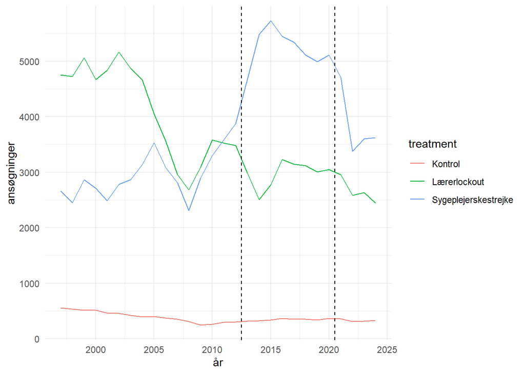

```r
df |>
  group_by(år, treatment) |>
  summarise(ansøgninger = mean(ansøgninger_prio1)) |>
  ggplot(aes(x = år, y = ansøgninger, color = treatment)) +
  geom_line() +
  geom_vline(xintercept = 2012.5, linetype = "dashed") +
  geom_vline(xintercept = 2020.5, linetype = "dashed") +
  theme_minimal()
```

**Absolutte tal, 3 kontrolgrupper**

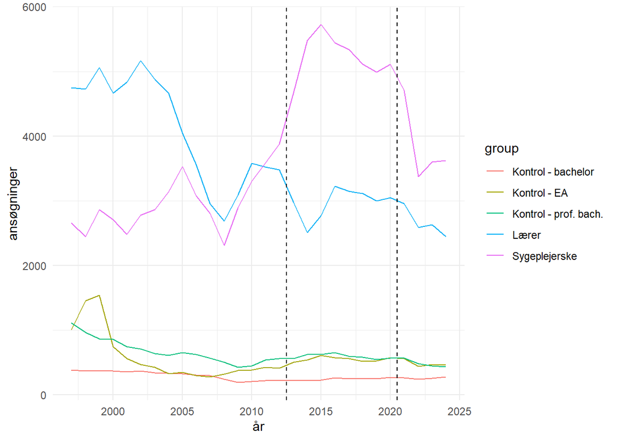

```r
df |>
  mutate(group = case_when(
    treatment == "Lærerlockout" ~ "Lærer",
    treatment == "Sygeplejerskestrejke" ~ "Sygeplejerske",
    uddannelsesniveau == "Bachelor" ~ "Kontrol - bachelor",
    uddannelsesniveau == "Prof. bachelor" ~ "Kontrol - prof. bach.",
    uddannelsesniveau == "Erhvervsakademi" ~ "Kontrol - EA"
  )) |>
  filter(!is.na(group)) |>
  group_by(group, år) |>
  summarise(ansøgninger = mean(ansøgninger_prio1)) |>
  ggplot(aes(x = år, y = ansøgninger, color = group)) +
  geom_line() +
  geom_vline(xintercept = 2012.5, linetype = "dashed") +
  geom_vline(xintercept = 2020.5, linetype = "dashed") +
  theme_minimal()
```

**Relative tal, 1 kontrolgruppe**

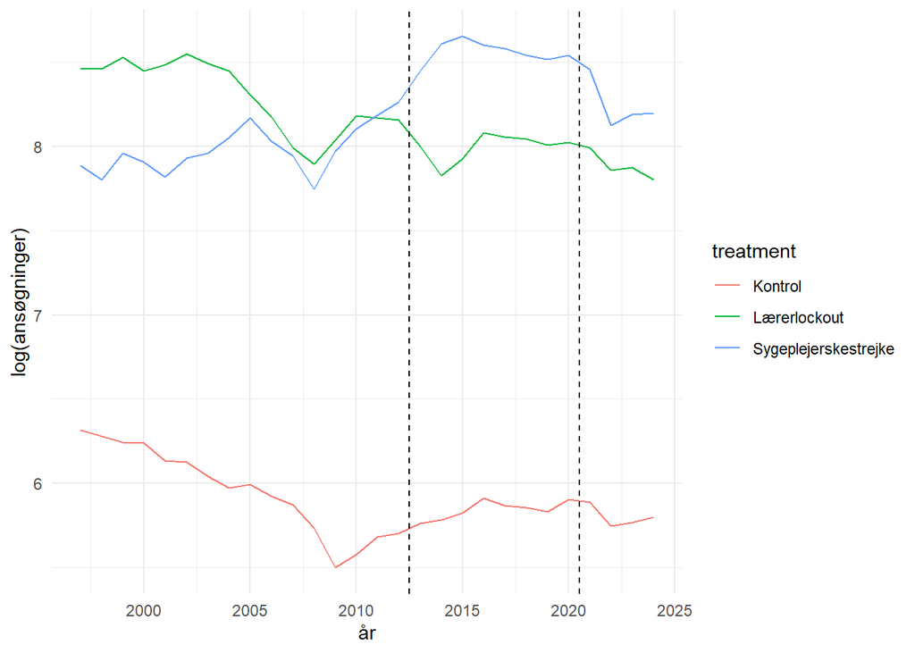

```r
df |>
  group_by(år, treatment) |>
  summarise(ansøgninger = mean(ansøgninger_prio1)) |>
  ggplot(aes(x = år, y = log(ansøgninger), color = treatment)) +
  geom_line() +
  geom_vline(xintercept = 2012.5, linetype = "dashed") +
  geom_vline(xintercept = 2020.5, linetype = "dashed") +
  theme_minimal()
```

**Relative tal, 3 kontrolgrupper**

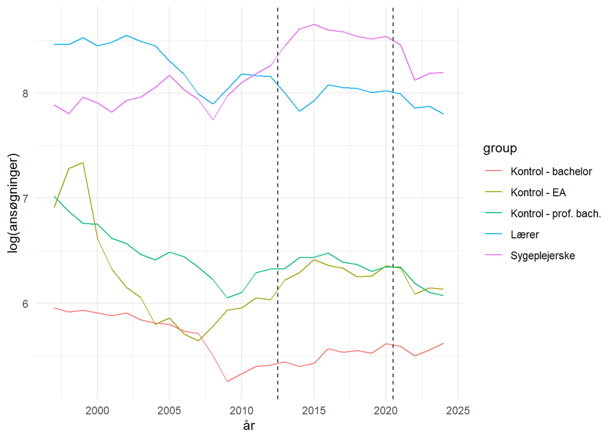

```r
df |>
  mutate(group = case_when(
    treatment == "Lærerlockout" ~ "Lærer",
    treatment == "Sygeplejerskestrejke" ~ "Sygeplejerske",
    uddannelsesniveau == "Bachelor" ~ "Kontrol - bachelor",
    uddannelsesniveau == "Prof. bachelor" ~ "Kontrol - prof. bach.",
    uddannelsesniveau == "Erhvervsakademi" ~ "Kontrol - EA"
  )) |>
  filter(!is.na(group)) |>
  group_by(group, år) |>
  summarise(ansøgninger = mean(ansøgninger_prio1)) |>
  ggplot(aes(x = år, y = log(ansøgninger), color = group)) +
  geom_line() +
  geom_vline(xintercept = 2012.5, linetype = "dashed") +
  geom_vline(xintercept = 2020.5, linetype = "dashed") +
  theme_minimal()
```

# 3 Hovedresultater

**Samlet**

### 3.0.1 Plots

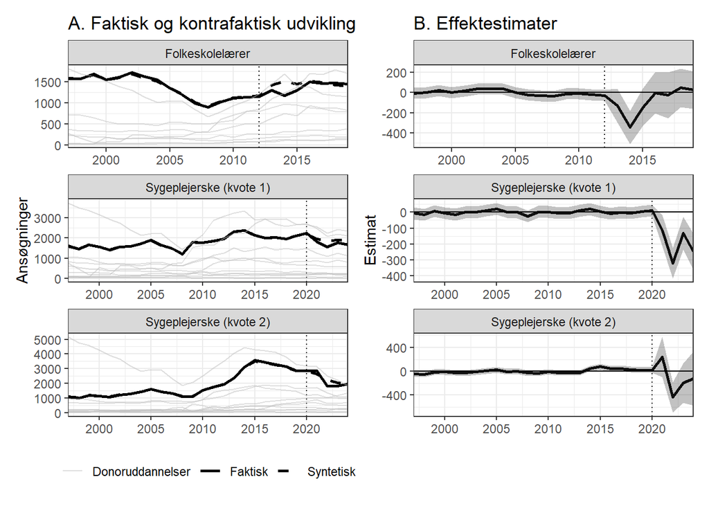

```r
# Laver data frame for lærere
ct_df_lærer <- data.frame(
  uddannelse = "Folkeskolelærer",
  t = as.vector(out_lærer[["time"]]),
  faktisk = as.vector(out_lærer[["Y.tr"]]),
  sk = as.vector(out_lærer[["Y.ct"]]),
  t0 = 2012)

controls_df_lærer <- cbind(ct_df_lærer, out_lærer[["Y.dat"]]) |>
  pivot_longer(cols = -c(uddannelse, t, faktisk, sk, t0),
               names_to = "kontrol_uddannelse",
               values_to = "ansøgere") |>
  filter(kontrol_uddannelse != "Folkeskolelærer")

# Laver data frame for sygeplejersker k1
ct_df_sygeplejersker_k1 <- data.frame(
  uddannelse = "Sygeplejerske (kvote 1)",
  t = as.vector(out_sygeplejersker_k1[["time"]]),
  faktisk = as.vector(out_sygeplejersker_k1[["Y.tr"]]),
  sk = as.vector(out_sygeplejersker_k1[["Y.ct"]]),
  t0 = 2020)

controls_df_sygeplejerske_k1 <- cbind(ct_df_sygeplejersker_k1, out_sygeplejersker_k1[["Y.dat"]]) |>
  pivot_longer(cols = -c(uddannelse, t, faktisk, sk, t0),
               names_to = "kontrol_uddannelse",
               values_to = "ansøgere") |>
  filter(kontrol_uddannelse != "Sygeplejerske (kvote 1)")

# Laver data frame for sygeplejersker k2
ct_df_sygeplejersker_k2 <- data.frame(
  uddannelse = "Sygeplejerske (kvote 2)",
  t = as.vector(out_sygeplejersker_k2[["time"]]),
  faktisk = as.vector(out_sygeplejersker_k2[["Y.tr"]]),
  sk = as.vector(out_sygeplejersker_k2[["Y.ct"]]),
  t0 = 2020)

controls_df_sygeplejerske_k2 <- cbind(ct_df_sygeplejersker_k2, out_sygeplejersker_k2[["Y.dat"]]) |>
  pivot_longer(cols = -c(uddannelse, t, faktisk, sk, t0),
               names_to = "kontrol_uddannelse",
               values_to = "ansøgere") |>
  filter(kontrol_uddannelse != "Sygeplejerske (kvote 2)")

# Samler til 1 data frame
ct_df <- rbind(
  ct_df_lærer[ct_df_lærer$t <= 2019,],
  ct_df_sygeplejersker_k1,
  ct_df_sygeplejersker_k2
)

complete_lærer <- df_lærer |>
  filter(år <= 2019 & !is.na(ansøgninger_main)) |>
  group_by(uddannelse) |>
  summarise(n = n()) |>
  filter(n == max(n))

complete_sygeplejerske_k1 <- df_sygeplejerske |>
  filter(!is.na(ansøgninger_main)) |>
  group_by(uddannelse) |>
  summarise(n = n()) |>
  filter(n == max(n))

complete_sygeplejerske_k2 <- df_sygeplejerske_k2 |>
  filter(!is.na(ansøgninger_main)) |>
  group_by(uddannelse) |>
  summarise(n = n()) |>
  filter(n == max(n))

controls_df <- rbind(
  controls_df_lærer[controls_df_lærer$t <= 2019,] |>
    filter(kontrol_uddannelse %in% complete_lærer$uddannelse),
  controls_df_sygeplejerske_k1 |>
    filter(kontrol_uddannelse %in% complete_sygeplejerske_k1$uddannelse),
  controls_df_sygeplejerske_k2 |>
    filter(kontrol_uddannelse %in% complete_sygeplejerske_k2$uddannelse)) |>
  filter(ansøgere > 0)

# Laver plot
ct_plots <- ct_df |>
  ggplot(aes(y = faktisk, x = t)) +
  geom_line(
    aes(linetype = "Faktisk"),
    color = "black",
    linewidth = 1) +
  geom_line(
    aes(y = sk, linetype = "Syntetisk"),
    linewidth = 1) +
  geom_vline(aes(xintercept = t0), linetype = "dotted") +
  geom_line(
    data = controls_df,
    aes(x = t, y = ansøgere, group = kontrol_uddannelse, linetype = "Donoruddannelser"),
    inherit.aes = FALSE,
    color = "grey",
    alpha = 0.5) +
  scale_linetype_manual(
    values = c(
      "Faktisk" = "solid",
      "Syntetisk" = "dashed",
      "Donoruddannelser" = "solid")) +
  scale_x_continuous(expand = c(0, 0)) +
  facet_wrap(~uddannelse, scales = "free", ncol = 1) +
  theme_bw() +
  theme(legend.position = "bottom") +
  labs(
    x = NULL,
    y = "Ansøgninger",
    linetype = NULL) +
  ggtitle("A. Faktisk og kontrafaktisk udvikling")

# Making gap data frames
# Bemærk: Pre-treatment konfidensintervaller beregnes pba. MSPE i CV.
# Man får dermed at den beregnes som sqrt(MSPE / N_pre)
gap_lærer <- ct_df_lærer |>
  mutate(estimate = faktisk - sk) |>
  bind_cols(as.data.frame(out_lærer[["est.att"]])) |>
  mutate(
    CI.lower = if_else(
      n.Treated == 0,
      estimate - 1.96 * sqrt(out_lærer[["MSPE"]] / sum(as.vector(out_lærer[["est.att"]][,"n.Treated"]) == 0)),
      CI.lower),
    CI.upper = if_else(
      n.Treated == 0,
      estimate + 1.96 * sqrt(out_lærer[["MSPE"]] / sum(as.vector(out_lærer[["est.att"]][,"n.Treated"]) == 0)),
      CI.upper))

gap_sygeplejersker_k1 <- ct_df_sygeplejersker_k1 |>
  mutate(estimate = faktisk - sk) |>
  bind_cols(as.data.frame(out_sygeplejersker_k1[["est.att"]])) |>
  mutate(
    CI.lower = if_else(
      n.Treated == 0,
      estimate - 1.96 * sqrt(out_sygeplejersker_k1[["MSPE"]] / sum(as.vector(out_sygeplejersker_k1[["est.att"]][,"n.Treated"]) == 0)),
      CI.lower),
    CI.upper = if_else(
      n.Treated == 0,
      estimate + 1.96 * sqrt(out_sygeplejersker_k1[["MSPE"]] / sum(as.vector(out_sygeplejersker_k1[["est.att"]][,"n.Treated"]) == 0)),
      CI.upper))

gap_sygeplejersker_k2 <- ct_df_sygeplejersker_k2 |>
  mutate(estimate = faktisk - sk) |>
  bind_cols(as.data.frame(out_sygeplejersker_k2[["est.att"]])) |>
  mutate(
    CI.lower = if_else(
      n.Treated == 0,
      estimate - 1.96 * sqrt(out_sygeplejersker_k2[["MSPE"]] / sum(as.vector(out_sygeplejersker_k2[["est.att"]][,"n.Treated"]) == 0)),
      CI.lower),
    CI.upper = if_else(
      n.Treated == 0,
      estimate + 1.96 * sqrt(out_sygeplejersker_k2[["MSPE"]] / sum(as.vector(out_sygeplejersker_k2[["est.att"]][,"n.Treated"]) == 0)),
      CI.upper))

gap_df <- rbind(
  gap_lærer[gap_lærer$t <= 2019,],
  gap_sygeplejersker_k1,
  gap_sygeplejersker_k2
)

gap_plots <- ggplot(gap_df, aes(x = t, y = estimate)) +
  geom_line(color = "black", linewidth = 1) +
  geom_ribbon(aes(ymin = CI.lower, ymax = CI.upper), alpha = 0.3) +
  geom_hline(yintercept = 0) +
  geom_vline(aes(xintercept = t0), linetype = "dotted") +
  facet_wrap(~uddannelse, ncol = 1, scales = "free") +
  scale_x_continuous(expand = c(0, 0)) +
  theme_bw() +
  labs(x = NULL,
       y = "Estimat") +
  ggtitle("B. Effektestimater")

ct_plots | gap_plots
```

```r
ggsave(filename = "plots/main_results.pdf",
       width = 9,
       height = 10)
```

### 3.0.2 Tabel

```r
resultater_lærer <- data.frame(
  uddannelse = "Folkeskolelærer",
  Term = c("T1", "T2", "T3", "T4"),
  Coefficient = c(
    gap_lærer$estimate[gap_lærer$t == 2013],
    gap_lærer$estimate[gap_lærer$t == 2014],
    gap_lærer$estimate[gap_lærer$t == 2015],
    gap_lærer$estimate[gap_lærer$t == 2016]
  ),
  Std.Error = c(
    gap_lærer$S.E.[gap_lærer$t == 2013],
    gap_lærer$S.E.[gap_lærer$t == 2014],
    gap_lærer$S.E.[gap_lærer$t == 2015],
    gap_lærer$S.E.[gap_lærer$t == 2016]
  ),
  p.Value = c(
    gap_lærer$p.value[gap_lærer$t == 2013],
    gap_lærer$p.value[gap_lærer$t == 2014],
    gap_lærer$p.value[gap_lærer$t == 2015],
    gap_lærer$p.value[gap_lærer$t == 2016]))

fm_lærer <- lm(Coefficient ~ Term, data = resultater_lærer)

resultater_sygeplejersker_k1 <- data.frame(
  uddannelse = "Sygeplejerske (kvote 1)",
  Term = c("T1", "T2", "T3", "T4"),
  Coefficient = c(
    gap_sygeplejersker_k1$estimate[gap_sygeplejersker_k1$t == 2021],
    gap_sygeplejersker_k1$estimate[gap_sygeplejersker_k1$t == 2022],
    gap_sygeplejersker_k1$estimate[gap_sygeplejersker_k1$t == 2023],
    gap_sygeplejersker_k1$estimate[gap_sygeplejersker_k1$t == 2024]
  ),
  Std.Error = c(
    gap_sygeplejersker_k1$S.E.[gap_sygeplejersker_k1$t == 2021],
    gap_sygeplejersker_k1$S.E.[gap_sygeplejersker_k1$t == 2022],
    gap_sygeplejersker_k1$S.E.[gap_sygeplejersker_k1$t == 2023],
    gap_sygeplejersker_k1$S.E.[gap_sygeplejersker_k1$t == 2024]
  ),
  p.Value = c(
    gap_sygeplejersker_k1$p.value[gap_sygeplejersker_k1$t == 2021],
    gap_sygeplejersker_k1$p.value[gap_sygeplejersker_k1$t == 2022],
    gap_sygeplejersker_k1$p.value[gap_sygeplejersker_k1$t == 2023],
    gap_sygeplejersker_k1$p.value[gap_sygeplejersker_k1$t == 2024]))

fm_sygeplejersker_k1 <- lm(Coefficient ~ Term, data = resultater_sygeplejersker_k1)

resultater_sygeplejersker_k2 <- data.frame(
  uddannelse = "Sygeplejerske (kvote 2)",
  Term = c("T1", "T2", "T3", "T4"),
  Coefficient = c(
    gap_sygeplejersker_k2$estimate[gap_sygeplejersker_k2$t == 2021],
    gap_sygeplejersker_k2$estimate[gap_sygeplejersker_k2$t == 2022],
    gap_sygeplejersker_k2$estimate[gap_sygeplejersker_k2$t == 2023],
    gap_sygeplejersker_k2$estimate[gap_sygeplejersker_k2$t == 2024]
  ),
  Std.Error = c(
    gap_sygeplejersker_k2$S.E.[gap_sygeplejersker_k2$t == 2021],
    gap_sygeplejersker_k2$S.E.[gap_sygeplejersker_k2$t == 2022],
    gap_sygeplejersker_k2$S.E.[gap_sygeplejersker_k2$t == 2023],
    gap_sygeplejersker_k2$S.E.[gap_sygeplejersker_k2$t == 2024]
  ),
  p.Value = c(
    gap_sygeplejersker_k2$p.value[gap_sygeplejersker_k2$t == 2021],
    gap_sygeplejersker_k2$p.value[gap_sygeplejersker_k2$t == 2022],
    gap_sygeplejersker_k2$p.value[gap_sygeplejersker_k2$t == 2023],
    gap_sygeplejersker_k2$p.value[gap_sygeplejersker_k2$t == 2024]))

fm_sygeplejersker_k2 <- lm(Coefficient ~ Term, data = resultater_sygeplejersker_k2)

rbind(resultater_lærer, resultater_sygeplejersker_k1, resultater_sygeplejersker_k2)
```

```
                uddannelse Term Coefficient Std.Error      p.Value
1          Folkeskolelærer   T1 -128.861169  84.68170 1.280813e-01
2          Folkeskolelærer   T2 -344.340379  84.15838 4.284522e-05
3          Folkeskolelærer   T3 -147.083602  93.70796 1.165092e-01
4          Folkeskolelærer   T4   -0.962603 103.74786 9.925971e-01
5  Sygeplejerske (kvote 1)   T1 -112.013676  49.96543 2.497278e-02
6  Sygeplejerske (kvote 1)   T2 -321.232977  48.67895 4.139067e-11
7  Sygeplejerske (kvote 1)   T3 -130.794370  52.83611 1.330598e-02
8  Sygeplejerske (kvote 1)   T4 -246.868299  57.44252 1.726124e-05
9  Sygeplejerske (kvote 2)   T1  239.660806 170.84022 1.606657e-01
10 Sygeplejerske (kvote 2)   T2 -435.694081 130.67868 8.557988e-04
11 Sygeplejerske (kvote 2)   T3 -194.197302 168.76527 2.498579e-01
12 Sygeplejerske (kvote 2)   T4 -119.302929 230.43694 6.046503e-01
```

**Folkeskolelærer**

### 3.0.3 Panelstrukturen

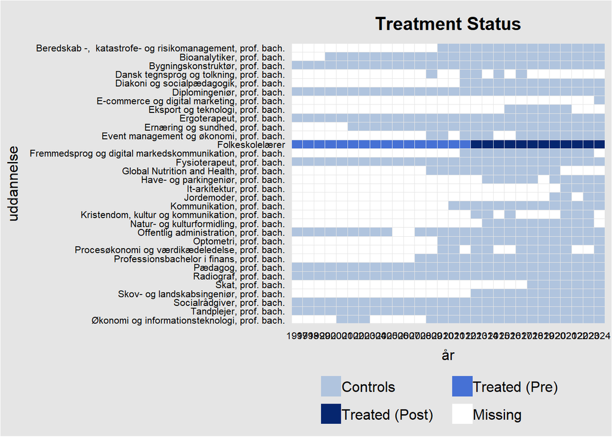

```r
gsk_df <- df_lærer |>
  filter(uddannelsesniveau == "Prof. bachelor" &
           treatment != "Sygeplejerskestrejke")

panelview(ansøgninger_main ~ d, index = c("uddannelse", "år"), pre.post = TRUE, data = gsk_df)
```

### 3.0.4 Udvikling i ansøgninger

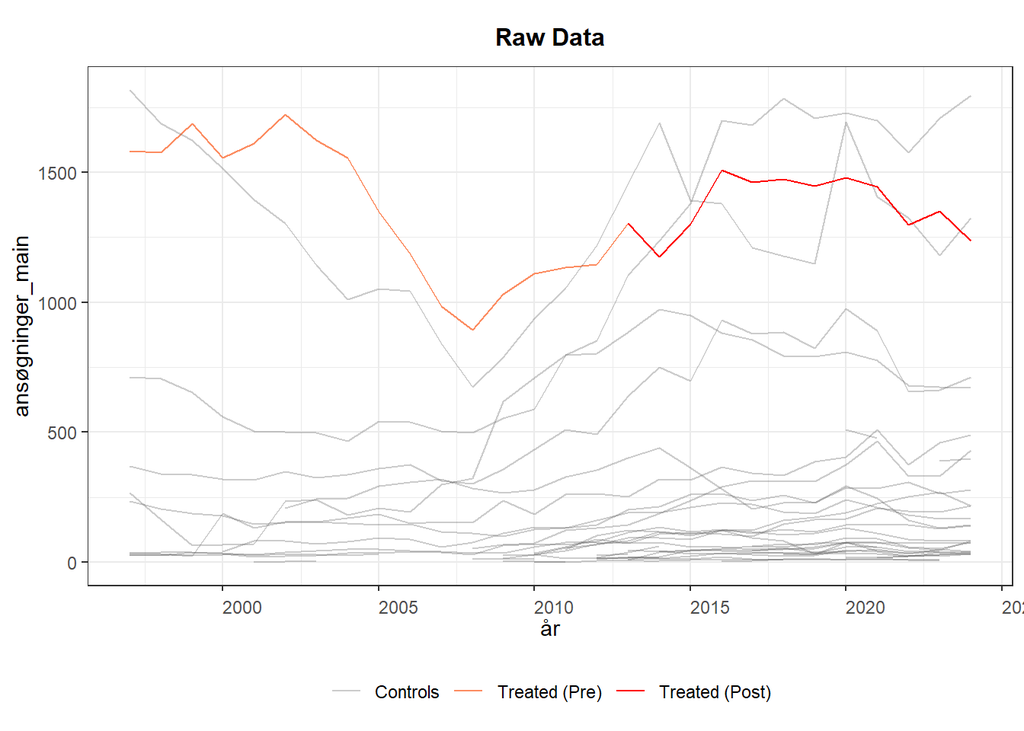

```r
panelview(ansøgninger_main ~ d, index = c("uddannelse", "år"), type = "outcome", data = gsk_df)
```

### 3.0.5 Syntetisk kontrol fit

```r
out <- gsynth(
  Y = "ansøgninger_main",
  D = "d",
  X = c("andel_kvinder_prio1", "karakter"),
  data = gsk_df,
  index = c("uddannelse", "år"),
  na.rm = TRUE,
  se = TRUE,
  force = "two-way",
  estimator = "mc",
  min.T0 = 5,
  nboots = 1000,
  seed = 4
)
```

```
Some treated units has too few pre-treatment periods.
They will be automatically removed.
Parallel computing ...
Cross-validating ...
 lambda.norm = 1.00000; MSPE = 48794.56042
 lambda.norm = 0.42170; MSPE = 37068.27863
 lambda.norm = 0.17783; MSPE = 23660.83907
 lambda.norm = 0.07499; MSPE = 14293.13389
 lambda.norm = 0.03162; MSPE = 12444.38288*
 lambda.norm = 0.01334; MSPE = 22394.05346
 lambda.norm = 0.00562; MSPE = 35692.09960
 lambda.norm = 0.00237; MSPE = 46523.55141
 lambda.norm = 0.00100; MSPE = 48429.59558
 lambda.norm = 0.00000; MSPE = 48794.56042

 lambda.norm* = 0.03162278


Bootstrapping ...

list of removed units: E-commerce og digital marketing, prof. bach. It-arkitektur, prof. bach. Jordemoder, prof. bach.
```

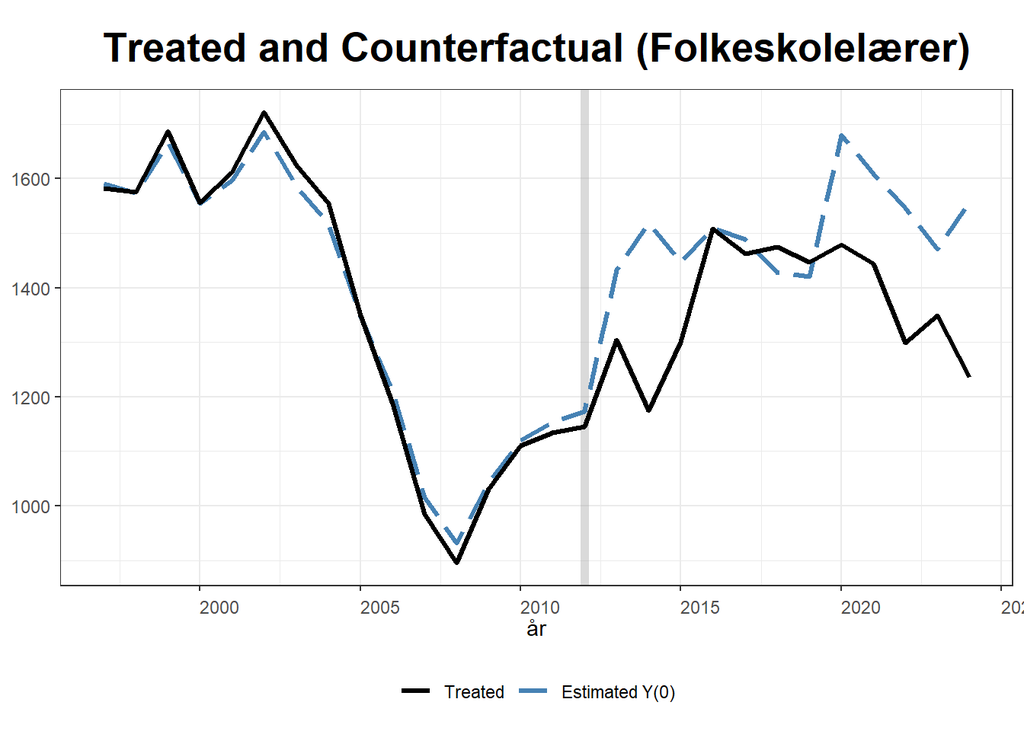

```r
plot(out, type = "ct")
```

### 3.0.6 Koefficient-plot

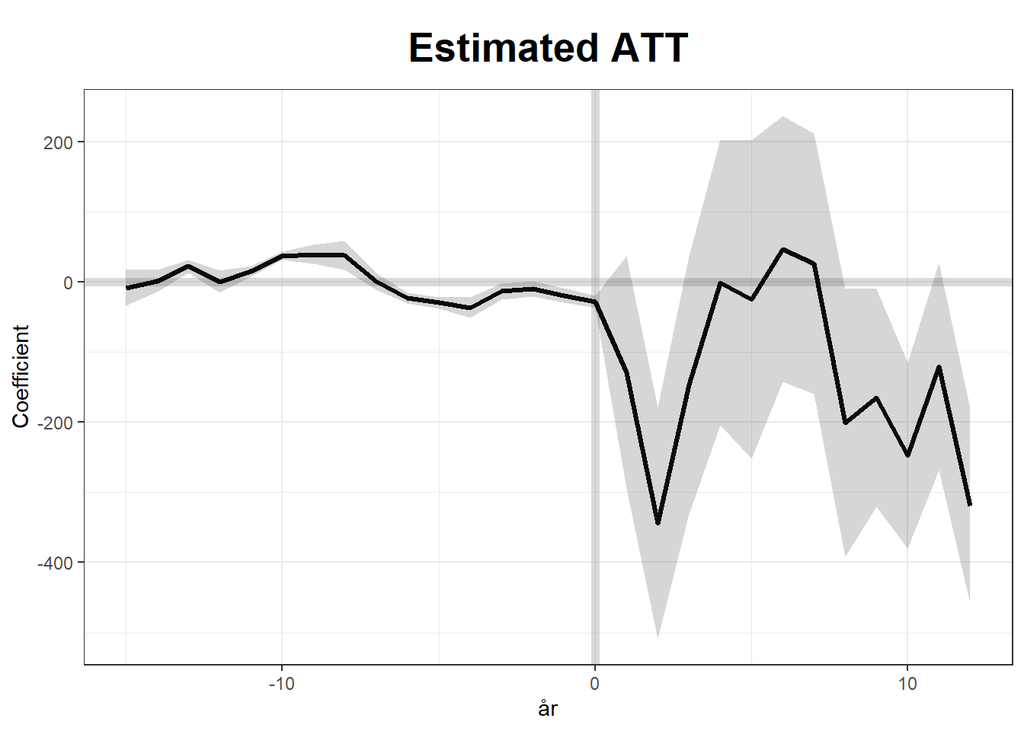

```r
plot(out, type = "gap")
```

### 3.0.7 Summary

```r
print(out)
```

```
Call:
gsynth.default(data = gsk_df, Y = "ansøgninger_main", D = "d",
    X = c("andel_kvinder_prio1", "karakter"), na.rm = TRUE, index = c("uddannelse",
        "år"), force = "two-way", estimator = "mc", se = TRUE,
    nboots = 1000, seed = 4, min.T0 = 5)

Average Treatment Effect on the Treated:
        Estimate  S.E. CI.lower CI.upper p.value
ATT.avg   -135.6 72.83   -278.4    7.096 0.06253

   ~ by Period (including Pre-treatment Periods):
          ATT    S.E. CI.lower CI.upper   p.value n.Treated
-15   -8.4906  12.970   -33.91   16.930 5.127e-01         0
-14    1.1895   8.062   -14.61   16.992 8.827e-01         0
-13   22.0980   4.741    12.81   31.390 3.147e-06         0
-12    0.3356   8.083   -15.51   16.179 9.669e-01         0
-11   15.2754   3.901     7.63   22.921 9.010e-05         0
-10   36.9706   3.150    30.80   43.144 0.000e+00         0
-9    39.3180   7.049    25.50   53.134 2.436e-08         0
-8    37.5379  10.460    17.04   58.039 3.323e-04         0
-7     1.2133   6.155   -10.85   13.277 8.437e-01         0
-6   -23.0903   3.909   -30.75  -15.430 3.472e-09         0
-5   -29.9628   4.240   -38.27  -21.652 1.590e-12         0
-4   -36.6922   7.552   -51.49  -21.891 1.181e-06         0
-3   -13.4017   5.750   -24.67   -2.133 1.976e-02         0
-2    -9.8375   5.647   -20.91    1.230 8.148e-02         0
-1   -19.4576   5.374   -29.99   -8.925 2.939e-04         0
0    -27.9710   4.396   -36.59  -19.355 1.981e-10         0
1   -128.8612  84.682  -294.83   37.112 1.281e-01         1
2   -344.3404  84.158  -509.29 -179.393 4.285e-05         1
3   -147.0836  93.708  -330.75   36.581 1.165e-01         1
4     -0.9626 103.748  -204.30  202.379 9.926e-01         1
5    -25.2795 115.892  -252.42  201.865 8.273e-01         1
6     46.9831  96.862  -142.86  236.829 6.276e-01         1
7     26.0935  94.657  -159.43  211.617 7.828e-01         1
8   -200.9960  97.604  -392.30   -9.697 3.946e-02         1
9   -165.5955  79.188  -320.80  -10.391 3.651e-02         1
10  -247.7850  67.374  -379.84 -115.734 2.353e-04         1
11  -120.5114  75.502  -268.49   27.470 1.105e-01         1
12  -319.3707  71.019  -458.57 -180.175 6.894e-06         1

Coefficients for the Covariates:
                      beta   S.E. CI.lower CI.upper p.value
andel_kvinder_prio1 113.08 273.96  -423.87   650.03  0.6798
karakter             16.38  31.34   -45.04    77.81  0.6011
```

**Sygeplejersker (kvote 1)**

### 3.0.8 Panelstrukturen

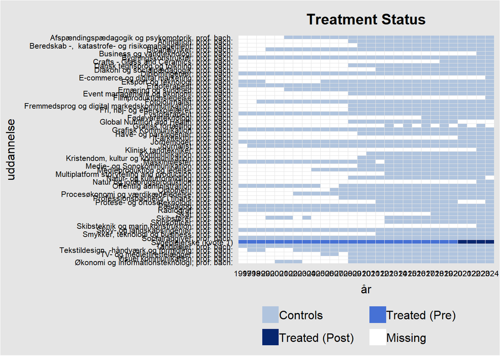

```r
gsk_df <- df_sygeplejerske |>
  filter(uddannelsesniveau == "Prof. bachelor" &
           treatment != "Lærerlockout" &
           uddannelse != "Sygeplejerske (kvote 2)")

panelview(ansøgninger_main ~ d, index = c("uddannelse", "år"), pre.post = TRUE, data = gsk_df)
```

### 3.0.9 Udvikling i ansøgninger

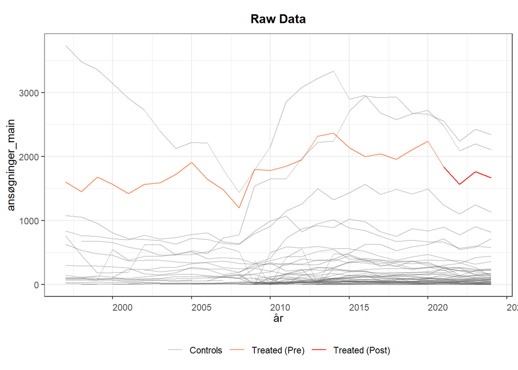

```r
panelview(ansøgninger_main ~ d, index = c("uddannelse", "år"), type = "outcome", data = gsk_df)
```

### 3.0.10 Syntetisk kontrol fit

```r
out <- gsynth(
  Y = "ansøgninger_main",
  D = "d",
  X = c("andel_kvinder_prio1"),
  data = gsk_df,
  index = c("uddannelse", "år"),
  na.rm = TRUE,
  se = TRUE,
  force = "two-way",
  estimator = "mc",
  min.T0 = 5,
  nboots = 1000,
  seed = 4,
  nlambda = 20
)
```

```
Some treated units has too few pre-treatment periods.
They will be automatically removed.
Parallel computing ...
Cross-validating ...
 lambda.norm = 1.00000; MSPE = 18053.14564
 lambda.norm = 0.68129; MSPE = 15722.46057
 lambda.norm = 0.46416; MSPE = 14258.82298
 lambda.norm = 0.31623; MSPE = 12548.08607
 lambda.norm = 0.21544; MSPE = 11207.32801
 lambda.norm = 0.14678; MSPE = 10104.37223
 lambda.norm = 0.10000; MSPE = 9717.71291
 lambda.norm = 0.06813; MSPE = 9519.00421
 lambda.norm = 0.04642; MSPE = 9296.79256*
 lambda.norm = 0.03162; MSPE = 9385.52104
 lambda.norm = 0.02154; MSPE = 9236.03079
 lambda.norm = 0.01468; MSPE = 8903.26418
 lambda.norm = 0.01000; MSPE = 8698.61404*
 lambda.norm = 0.00681; MSPE = 9022.67256
 lambda.norm = 0.00464; MSPE = 10464.07512
 lambda.norm = 0.00316; MSPE = 12706.26085
 lambda.norm = 0.00215; MSPE = 16893.99271
 lambda.norm = 0.00147; MSPE = 17370.85113
 lambda.norm = 0.00100; MSPE = 17581.98335
 lambda.norm = 0.00000; MSPE = 18045.54889

 lambda.norm* = 0.01


Bootstrapping ...

list of removed units: Business og vandteknologi, prof. bach. E-commerce og digital marketing, prof. bach. Filmproduktionsledelse, prof. bach. It-arkitektur, prof. bach. Klinisk tandtekniker, prof. bach. Natur og jordbrugsproduktion, prof. bach. Skibsteknik og marin konstruktion, prof. bach.
```

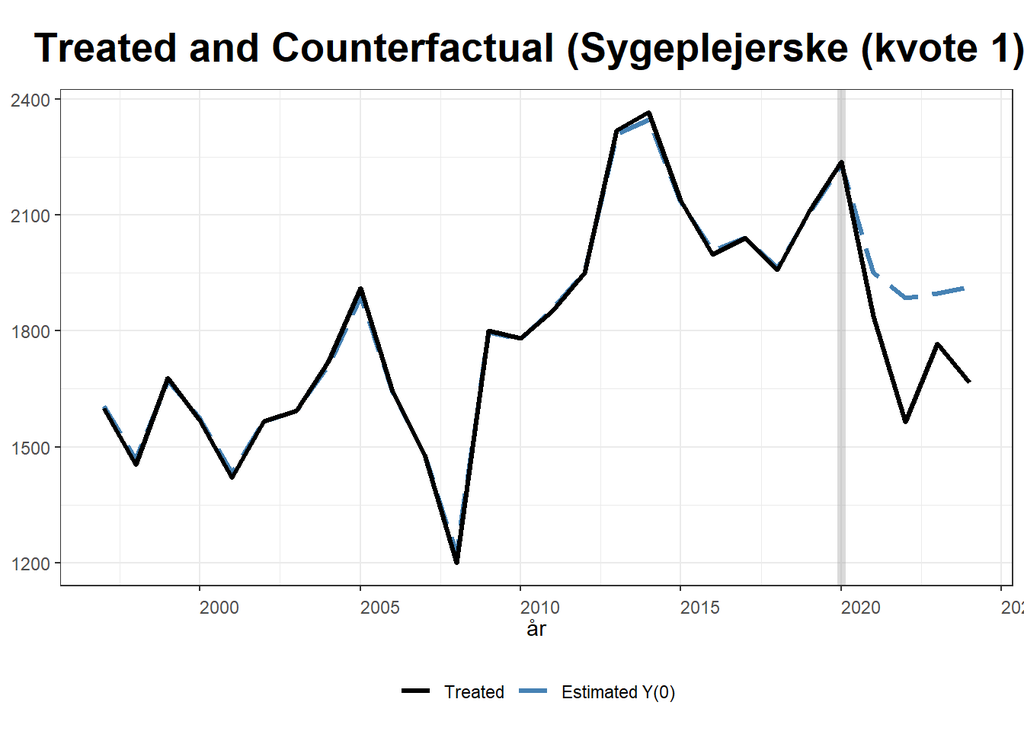

```r
plot(out, type = "ct")
```

### 3.0.11 Koefficient-plot

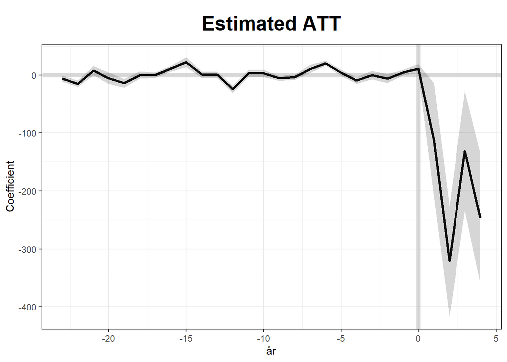

```r
plot(out, type = "gap")
```

### 3.0.12 Summary

```r
print(out)
```

```
Call:
gsynth.default(data = gsk_df, Y = "ansøgninger_main", D = "d",
    X = c("andel_kvinder_prio1"), na.rm = TRUE, index = c("uddannelse",
        "år"), force = "two-way", nlambda = 20, estimator = "mc",
    se = TRUE, nboots = 1000, seed = 4, min.T0 = 5)

Average Treatment Effect on the Treated:
        Estimate  S.E. CI.lower CI.upper  p.value
ATT.avg   -202.7 48.22   -297.2   -108.2 2.62e-05

   ~ by Period (including Pre-treatment Periods):
           ATT   S.E. CI.lower  CI.upper   p.value n.Treated
-23   -6.10643  2.594  -11.191   -1.0214 1.859e-02         0
-22  -14.77893  2.742  -20.152   -9.4054 7.025e-08         0
-21    7.52727  3.906   -0.129   15.1836 5.399e-02         0
-20   -5.48267  4.948  -15.181    4.2157 2.679e-01         0
-19  -14.05861  3.771  -21.450   -6.6669 1.932e-04         0
-18    0.02058  3.111   -6.076    6.1176 9.947e-01         0
-17   -0.16954  2.404   -4.881    4.5416 9.438e-01         0
-16   10.89541  2.498    6.000   15.7907 1.287e-05         0
-15   22.16372  4.357   13.625   30.7027 3.633e-07         0
-14    0.94603  2.734   -4.413    6.3050 7.293e-01         0
-13    0.32580  2.817   -5.196    5.8474 9.079e-01         0
-12  -24.31199  3.198  -30.579  -18.0447 2.887e-14         0
-11    2.92320  3.035   -3.025    8.8709 3.354e-01         0
-10    2.90151  3.226   -3.422    9.2246 3.685e-01         0
-9    -5.61502  2.047   -9.628   -1.6023 6.096e-03         0
-8    -3.58337  2.293   -8.077    0.9103 1.181e-01         0
-7    10.47828  3.561    3.498   17.4581 3.257e-03         0
-6    20.23037  2.186   15.946   24.5143 0.000e+00         0
-5     3.58366  2.658   -1.625    8.7924 1.775e-01         0
-4    -8.98497  2.970  -14.806   -3.1639 2.484e-03         0
-3    -0.27907  3.669   -7.471    6.9128 9.394e-01         0
-2    -5.83313  3.981  -13.636    1.9695 1.429e-01         0
-1     4.31789  2.400   -0.386    9.0218 7.200e-02         0
0     11.01223  3.905    3.359   18.6657 4.801e-03         0
1   -112.01368 49.965 -209.944  -14.0832 2.497e-02         1
2   -321.23298 48.679 -416.642 -225.8240 4.139e-11         1
3   -130.79437 52.836 -234.351  -27.2375 1.331e-02         1
4   -246.86830 57.443 -359.454 -134.2830 1.726e-05         1

Coefficients for the Covariates:
                     beta  S.E. CI.lower CI.upper p.value
andel_kvinder_prio1 261.1 165.4   -63.16    585.3  0.1145
```

**Sygeplejersker (kvote 2)**

### 3.0.13 Panelstrukturen

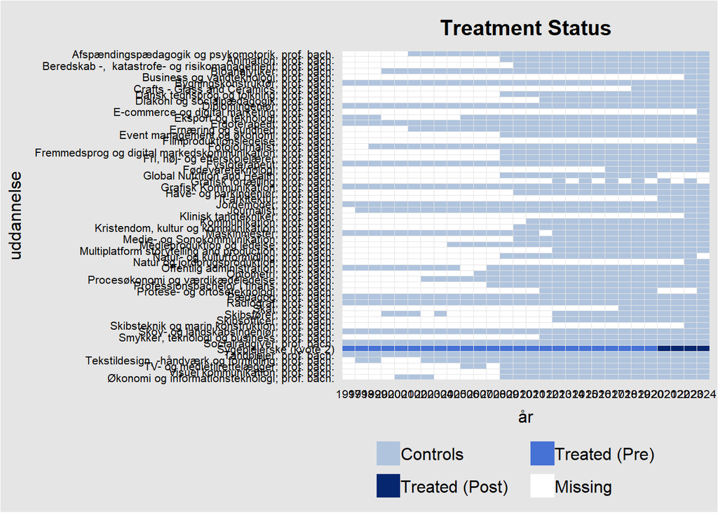

```r
gsk_df <- df_sygeplejerske_k2 |>
  filter(uddannelsesniveau == "Prof. bachelor" &
           treatment != "Lærerlockout" &
           uddannelse != "Sygeplejerske (kvote 1)")

panelview(ansøgninger_main ~ d, index = c("uddannelse", "år"), pre.post = TRUE, data = gsk_df)
```

### 3.0.14 Udvikling i ansøgninger

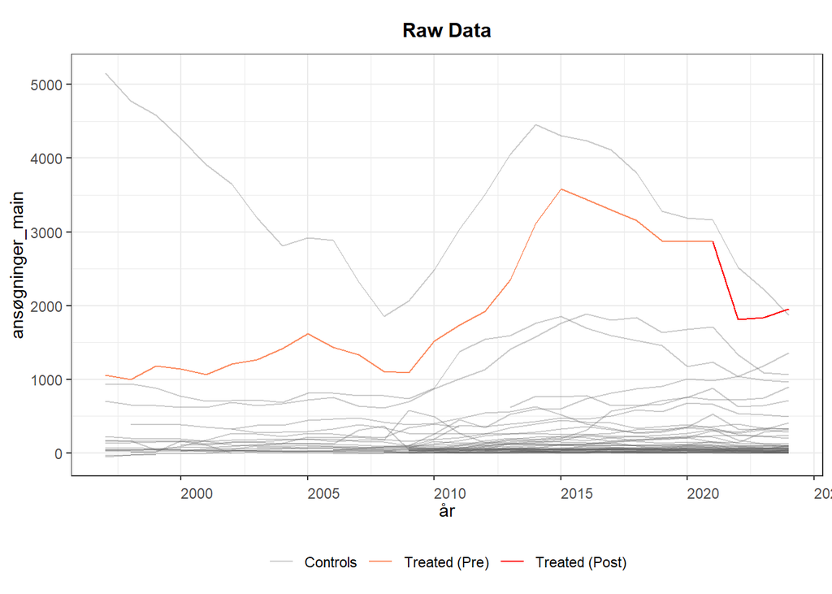

```r
panelview(ansøgninger_main ~ d, index = c("uddannelse", "år"), type = "outcome", data = gsk_df)
```

### 3.0.15 Syntetisk kontrol fit

```r
out <- gsynth(
  Y = "ansøgninger_main",
  D = "d",
  X = c("andel_kvinder_prio1"),
  data = gsk_df,
  index = c("uddannelse", "år"),
  na.rm = TRUE,
  se = TRUE,
  force = "two-way",
  estimator = "mc",
  min.T0 = 5,
  nboots = 1000,
  seed = 4,
  nlambda = 20
)
```

```
Some treated units has too few pre-treatment periods.
They will be automatically removed.
Parallel computing ...
Cross-validating ...
 lambda.norm = 1.00000; MSPE = 64361.95141
 lambda.norm = 0.68129; MSPE = 52128.42419
 lambda.norm = 0.46416; MSPE = 39692.16652
 lambda.norm = 0.31623; MSPE = 31585.62169
 lambda.norm = 0.21544; MSPE = 24851.51938
 lambda.norm = 0.14678; MSPE = 20061.88197
 lambda.norm = 0.10000; MSPE = 17856.19937
 lambda.norm = 0.06813; MSPE = 16182.24788
 lambda.norm = 0.04642; MSPE = 15027.08034
 lambda.norm = 0.03162; MSPE = 14257.12157*
 lambda.norm = 0.02154; MSPE = 14493.84388
 lambda.norm = 0.01468; MSPE = 17093.91688
 lambda.norm = 0.01000; MSPE = 23291.54074
 lambda.norm = 0.00681; MSPE = 32182.79553
 lambda.norm = 0.00464; MSPE = 41583.50564
 lambda.norm = 0.00316; MSPE = 51200.19153
 lambda.norm = 0.00215; MSPE = 61852.09181
 lambda.norm = 0.00147; MSPE = 63024.90096
 lambda.norm = 0.00100; MSPE = 63419.66803
 lambda.norm = 0.00000; MSPE = 64278.87908

 lambda.norm* = 0.03162278


Bootstrapping ...

list of removed units: Business og vandteknologi, prof. bach. E-commerce og digital marketing, prof. bach. Filmproduktionsledelse, prof. bach. It-arkitektur, prof. bach. Klinisk tandtekniker, prof. bach. Natur og jordbrugsproduktion, prof. bach. Skibsteknik og marin konstruktion, prof. bach.
```

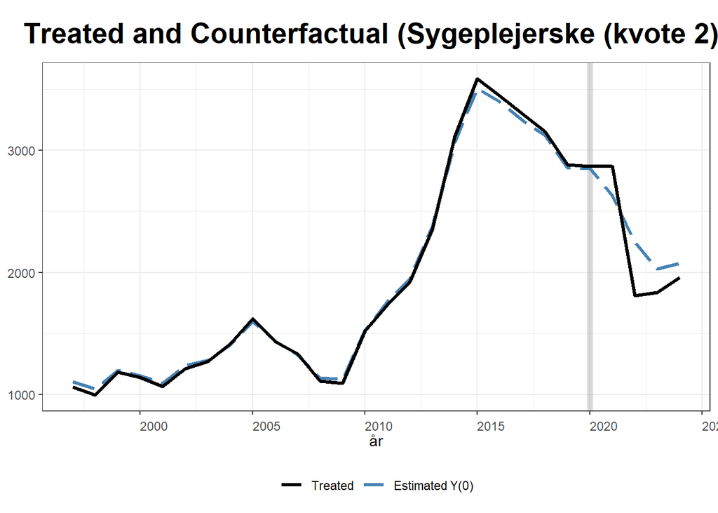

```r
plot(out, type = "ct")
```

### 3.0.16 Koefficient-plot

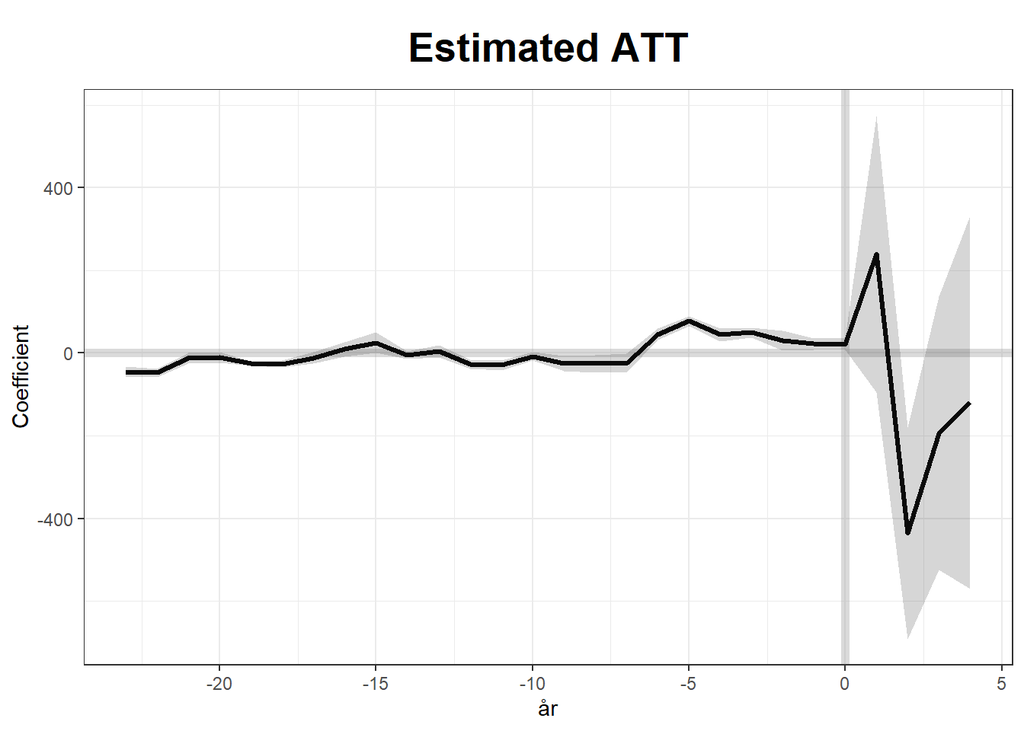

```r
plot(out, type = "gap")
```

### 3.0.17 Summary

```r
print(out)
```

```
Call:
gsynth.default(data = gsk_df, Y = "ansøgninger_main", D = "d",
    X = c("andel_kvinder_prio1"), na.rm = TRUE, index = c("uddannelse",
        "år"), force = "two-way", nlambda = 20, estimator = "mc",
    se = TRUE, nboots = 1000, seed = 4, min.T0 = 5)

Average Treatment Effect on the Treated:
        Estimate  S.E. CI.lower CI.upper p.value
ATT.avg   -127.4 134.1   -390.3    135.5  0.3423

   ~ by Period (including Pre-treatment Periods):
         ATT    S.E. CI.lower   CI.upper   p.value n.Treated
-23  -44.416   5.959  -56.094  -32.73694 9.059e-14         0
-22  -47.810   5.040  -57.689  -37.93200 0.000e+00         0
-21  -12.022   6.151  -24.077    0.03361 5.064e-02         0
-20  -10.030   6.980  -23.710    3.64962 1.507e-01         0
-19  -25.099   3.141  -31.254  -18.94324 1.332e-15         0
-18  -25.963   4.092  -33.982  -17.94324 2.221e-10         0
-17  -11.137   6.911  -24.682    2.40739 1.070e-01         0
-16    9.245   8.825   -8.051   26.54134 2.948e-01         0
-15   25.658  12.437    1.282   50.03471 3.911e-02         0
-14   -4.679   4.326  -13.157    3.79963 2.794e-01         0
-13    5.181   7.416   -9.354   19.71666 4.848e-01         0
-12  -26.450   5.438  -37.108  -15.79154 1.151e-06         0
-11  -29.371   6.367  -41.849  -16.89271 3.963e-06         0
-10   -7.399   5.565  -18.307    3.50858 1.837e-01         0
-9   -24.549   9.266  -42.710   -6.38842 8.063e-03         0
-8   -25.439  10.769  -46.546   -4.33223 1.816e-02         0
-7   -24.167  11.715  -47.128   -1.20651 3.912e-02         0
-6    46.009   7.464   31.380   60.63820 7.084e-10         0
-5    77.524   6.467   64.849   90.19912 0.000e+00         0
-4    44.832   8.064   29.026   60.63751 2.707e-08         0
-3    49.743   6.138   37.712   61.77380 4.441e-16         0
-2    30.169  12.166    6.324   54.01426 1.315e-02         0
-1    22.249   6.871    8.782   35.71569 1.203e-03         0
0     21.541   7.229    7.373   35.70822 2.883e-03         0
1    239.661 170.840  -95.180  574.50148 1.607e-01         1
2   -435.694 130.679 -691.820 -179.56858 8.558e-04         1
3   -194.197 168.765 -524.971  136.57655 2.499e-01         1
4   -119.303 230.437 -570.951  332.34517 6.047e-01         1

Coefficients for the Covariates:
                      beta  S.E. CI.lower CI.upper p.value
andel_kvinder_prio1 -62.56 140.2   -337.4    212.3  0.6555
```

# 4 Robusthedstests

**Figur til paper**

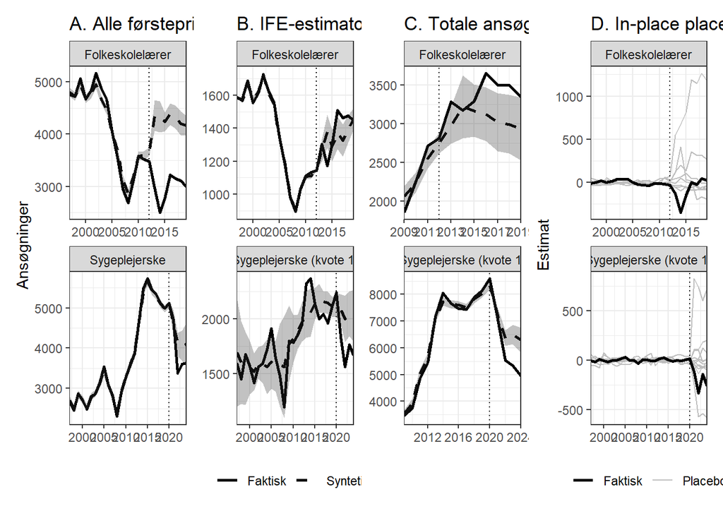

```r
plot_alle_ansøgninger | plot_ife | plot_totale_ansøgninger | plot_placebo
```

```r
ggsave(filename = "plots/robusthedstests.pdf",
       width = 16,
       height = 9)
```

**Balanceret tidsserie**

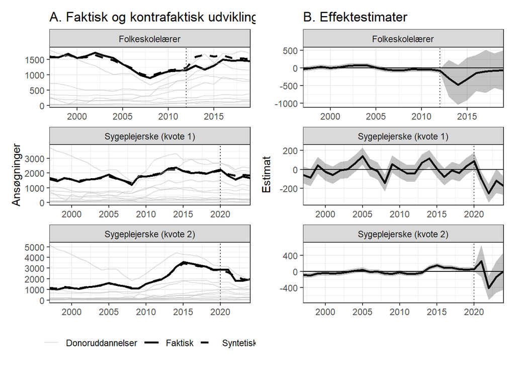

```r
# Laver data frame for lærere
ct_df_lærer <- data.frame(
  uddannelse = "Folkeskolelærer",
  t = as.vector(out_lærer[["time"]]),
  faktisk = as.vector(out_lærer[["Y.tr"]]),
  sk = as.vector(out_lærer[["Y.ct"]]),
  t0 = 2012)

controls_df_lærer <- cbind(ct_df_lærer, out_lærer[["Y.dat"]]) |>
  pivot_longer(cols = -c(uddannelse, t, faktisk, sk, t0),
               names_to = "kontrol_uddannelse",
               values_to = "ansøgere") |>
  filter(kontrol_uddannelse != "Folkeskolelærer")

# Laver data frame for sygeplejersker k1
ct_df_sygeplejersker_k1 <- data.frame(
  uddannelse = "Sygeplejerske (kvote 1)",
  t = as.vector(out_sygeplejersker_k1[["time"]]),
  faktisk = as.vector(out_sygeplejersker_k1[["Y.tr"]]),
  sk = as.vector(out_sygeplejersker_k1[["Y.ct"]]),
  t0 = 2020)

controls_df_sygeplejerske_k1 <- cbind(ct_df_sygeplejersker_k1, out_sygeplejersker_k1[["Y.dat"]]) |>
  pivot_longer(cols = -c(uddannelse, t, faktisk, sk, t0),
               names_to = "kontrol_uddannelse",
               values_to = "ansøgere") |>
  filter(kontrol_uddannelse != "Sygeplejerske (kvote 1)")

# Laver data frame for sygeplejersker k2
ct_df_sygeplejersker_k2 <- data.frame(
  uddannelse = "Sygeplejerske (kvote 2)",
  t = as.vector(out_sygeplejersker_k2[["time"]]),
  faktisk = as.vector(out_sygeplejersker_k2[["Y.tr"]]),
  sk = as.vector(out_sygeplejersker_k2[["Y.ct"]]),
  t0 = 2020)

controls_df_sygeplejerske_k2 <- cbind(ct_df_sygeplejersker_k2, out_sygeplejersker_k2[["Y.dat"]]) |>
  pivot_longer(cols = -c(uddannelse, t, faktisk, sk, t0),
               names_to = "kontrol_uddannelse",
               values_to = "ansøgere") |>
  filter(kontrol_uddannelse != "Sygeplejerske (kvote 2)")

# Samler til 1 data frame
ct_df <- rbind(
  ct_df_lærer[ct_df_lærer$t <= 2019,],
  ct_df_sygeplejersker_k1,
  ct_df_sygeplejersker_k2
)

controls_df <- rbind(
  controls_df_lærer[controls_df_lærer$t <= 2019,],
  controls_df_sygeplejerske_k1,
  controls_df_sygeplejerske_k2) |>
  filter(ansøgere > 0)

# Laver plot
ct_plots <- ct_df |>
  ggplot(aes(y = faktisk, x = t)) +
  geom_line(
    aes(linetype = "Faktisk"),
    color = "black",
    linewidth = 1) +
  geom_line(
    aes(y = sk, linetype = "Syntetisk"),
    linewidth = 1) +
  geom_vline(aes(xintercept = t0), linetype = "dotted") +
  geom_line(
    data = controls_df,
    aes(x = t, y = ansøgere, group = kontrol_uddannelse, linetype = "Donoruddannelser"),
    inherit.aes = FALSE,
    color = "grey",
    alpha = 0.5) +
  scale_linetype_manual(
    values = c(
      "Faktisk" = "solid",
      "Syntetisk" = "dashed",
      "Donoruddannelser" = "solid")) +
  scale_x_continuous(expand = c(0, 0)) +
  facet_wrap(~uddannelse, scales = "free", ncol = 1) +
  theme_bw() +
  theme(legend.position = "bottom") +
  labs(
    x = NULL,
    y = "Ansøgninger",
    linetype = NULL) +
  ggtitle("A. Faktisk og kontrafaktisk udvikling")

# Making gap data frames
# Bemærk: Pre-treatment konfidensintervaller beregnes pba. MSPE i CV.
# Man får dermed at den beregnes som sqrt(MSPE / N_pre)
gap_lærer <- ct_df_lærer |>
  mutate(estimate = faktisk - sk) |>
  bind_cols(as.data.frame(out_lærer[["est.att"]])) |>
  mutate(
    CI.lower = if_else(
      n.Treated == 0,
      estimate - 1.96 * sqrt(out_lærer[["MSPE"]] / sum(as.vector(out_lærer[["est.att"]][,"n.Treated"]) == 0)),
      CI.lower),
    CI.upper = if_else(
      n.Treated == 0,
      estimate + 1.96 * sqrt(out_lærer[["MSPE"]] / sum(as.vector(out_lærer[["est.att"]][,"n.Treated"]) == 0)),
      CI.upper))

gap_sygeplejersker_k1 <- ct_df_sygeplejersker_k1 |>
  mutate(estimate = faktisk - sk) |>
  bind_cols(as.data.frame(out_sygeplejersker_k1[["est.att"]])) |>
  mutate(
    CI.lower = if_else(
      n.Treated == 0,
      estimate - 1.96 * sqrt(out_sygeplejersker_k1[["MSPE"]] / sum(as.vector(out_sygeplejersker_k1[["est.att"]][,"n.Treated"]) == 0)),
      CI.lower),
    CI.upper = if_else(
      n.Treated == 0,
      estimate + 1.96 * sqrt(out_sygeplejersker_k1[["MSPE"]] / sum(as.vector(out_sygeplejersker_k1[["est.att"]][,"n.Treated"]) == 0)),
      CI.upper))

gap_sygeplejersker_k2 <- ct_df_sygeplejersker_k2 |>
  mutate(estimate = faktisk - sk) |>
  bind_cols(as.data.frame(out_sygeplejersker_k2[["est.att"]])) |>
  mutate(
    CI.lower = if_else(
      n.Treated == 0,
      estimate - 1.96 * sqrt(out_sygeplejersker_k2[["MSPE"]] / sum(as.vector(out_sygeplejersker_k2[["est.att"]][,"n.Treated"]) == 0)),
      CI.lower),
    CI.upper = if_else(
      n.Treated == 0,
      estimate + 1.96 * sqrt(out_sygeplejersker_k2[["MSPE"]] / sum(as.vector(out_sygeplejersker_k2[["est.att"]][,"n.Treated"]) == 0)),
      CI.upper))

gap_df <- rbind(
  gap_lærer[gap_lærer$t <= 2019,],
  gap_sygeplejersker_k1,
  gap_sygeplejersker_k2
)

gap_plots <- ggplot(gap_df, aes(x = t, y = estimate)) +
  geom_line(color = "black", linewidth = 1) +
  geom_ribbon(aes(ymin = CI.lower, ymax = CI.upper), alpha = 0.3) +
  geom_hline(yintercept = 0) +
  geom_vline(aes(xintercept = t0), linetype = "dotted") +
  facet_wrap(~uddannelse, ncol = 1, scales = "free") +
  scale_x_continuous(expand = c(0, 0)) +
  theme_bw() +
  labs(x = NULL,
       y = "Estimat") +
  ggtitle("B. Effektestimater")

ct_plots | gap_plots
```

**Ansøgninger ikke opdelt**

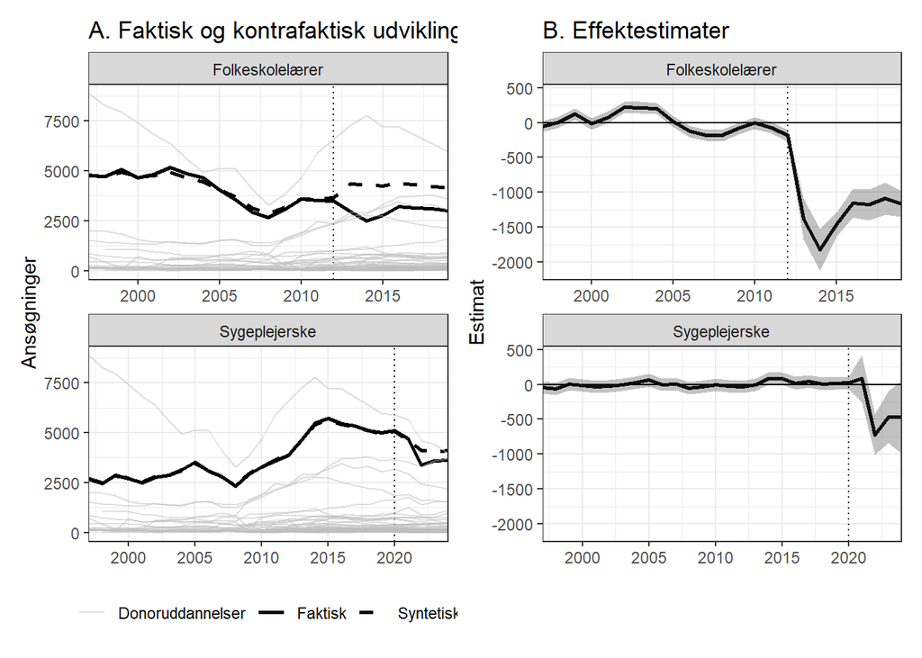

```r
# Laver data frame for lærere
ct_df_lærer <- data.frame(
  uddannelse = "Folkeskolelærer",
  t = as.vector(out_lærer[["time"]]),
  faktisk = as.vector(out_lærer[["Y.tr"]]),
  sk = as.vector(out_lærer[["Y.ct"]]),
  t0 = 2012)

controls_df_lærer <- cbind(ct_df_lærer, out_lærer[["Y.dat"]]) |>
  pivot_longer(cols = -c(uddannelse, t, faktisk, sk, t0),
               names_to = "kontrol_uddannelse",
               values_to = "ansøgere") |>
  filter(kontrol_uddannelse != "Folkeskolelærer (alle)")

# Laver data frame for sygeplejersker k1
ct_df_sygeplejersker <- data.frame(
  uddannelse = "Sygeplejerske",
  t = as.vector(out_sygeplejersker[["time"]]),
  faktisk = as.vector(out_sygeplejersker[["Y.tr"]]),
  sk = as.vector(out_sygeplejersker[["Y.ct"]]),
  t0 = 2020)

controls_df_sygeplejerske <- cbind(ct_df_sygeplejersker, out_sygeplejersker[["Y.dat"]]) |>
  pivot_longer(cols = -c(uddannelse, t, faktisk, sk, t0),
               names_to = "kontrol_uddannelse",
               values_to = "ansøgere") |>
  filter(kontrol_uddannelse != "Sygeplejerske (alle)")

# Samler til 1 data frame
ct_df <- rbind(
  ct_df_lærer[ct_df_lærer$t <= 2019,],
  ct_df_sygeplejersker
)

controls_df <- rbind(
  controls_df_lærer[controls_df_lærer$t <= 2019,],
  controls_df_sygeplejerske) |>
  filter(ansøgere > 0)

# Laver plot
ct_plots <- ct_df |>
  ggplot(aes(y = faktisk, x = t)) +
  geom_line(
    aes(linetype = "Faktisk"),
    color = "black",
    linewidth = 1) +
  geom_line(
    aes(y = sk, linetype = "Syntetisk"),
    linewidth = 1) +
  geom_vline(aes(xintercept = t0), linetype = "dotted") +
  geom_line(
    data = controls_df,
    aes(x = t, y = ansøgere, group = kontrol_uddannelse, linetype = "Donoruddannelser"),
    inherit.aes = FALSE,
    color = "grey",
    alpha = 0.5) +
  scale_linetype_manual(
    values = c(
      "Faktisk" = "solid",
      "Syntetisk" = "dashed",
      "Donoruddannelser" = "solid")) +
  scale_x_continuous(expand = c(0, 0)) +
  facet_wrap(~uddannelse, scales = "free", ncol = 1) +
  theme_bw() +
  theme(legend.position = "bottom") +
  labs(
    x = NULL,
    y = "Ansøgninger",
    linetype = NULL) +
  ggtitle("A. Faktisk og kontrafaktisk udvikling")

# Making gap data frames
# Bemærk: Pre-treatment konfidensintervaller beregnes pba. MSPE i CV.
# Man får dermed at den beregnes som sqrt(MSPE / N_pre)
gap_lærer <- ct_df_lærer |>
  mutate(estimate = faktisk - sk) |>
  bind_cols(as.data.frame(out_lærer[["est.att"]])) |>
  mutate(
    CI.lower = if_else(
      n.Treated == 0,
      estimate - 1.96 * sqrt(out_lærer[["MSPE"]] / sum(as.vector(out_lærer[["est.att"]][,"n.Treated"]) == 0)),
      CI.lower),
    CI.upper = if_else(
      n.Treated == 0,
      estimate + 1.96 * sqrt(out_lærer[["MSPE"]] / sum(as.vector(out_lærer[["est.att"]][,"n.Treated"]) == 0)),
      CI.upper))

gap_sygeplejersker <- ct_df_sygeplejersker |>
  mutate(estimate = faktisk - sk) |>
  bind_cols(as.data.frame(out_sygeplejersker[["est.att"]])) |>
  mutate(
    CI.lower = if_else(
      n.Treated == 0,
      estimate - 1.96 * sqrt(out_sygeplejersker[["MSPE"]] / sum(as.vector(out_sygeplejersker[["est.att"]][,"n.Treated"]) == 0)),
      CI.lower),
    CI.upper = if_else(
      n.Treated == 0,
      estimate + 1.96 * sqrt(out_sygeplejersker[["MSPE"]] / sum(as.vector(out_sygeplejersker[["est.att"]][,"n.Treated"]) == 0)),
      CI.upper))

gap_df <- rbind(
  gap_lærer[gap_lærer$t <= 2019,],
  gap_sygeplejersker
)

gap_plots <- ggplot(gap_df, aes(x = t, y = estimate)) +
  geom_line(color = "black", linewidth = 1) +
  geom_ribbon(aes(ymin = CI.lower, ymax = CI.upper), alpha = 0.3) +
  geom_hline(yintercept = 0) +
  geom_vline(aes(xintercept = t0), linetype = "dotted") +
  facet_wrap(~uddannelse, ncol = 1, scales = "free_x") +
  scale_x_continuous(expand = c(0, 0)) +
  theme_bw() +
  labs(x = NULL,
       y = "Estimat") +
  ggtitle("B. Effektestimater")

ct_plots | gap_plots
```

**IFE-estimator**

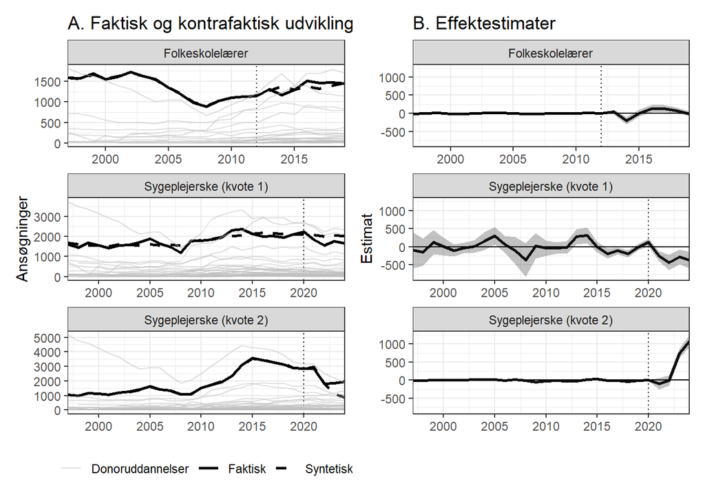

```r
# Laver data frame for lærere
ct_df_lærer <- data.frame(
  uddannelse = "Folkeskolelærer",
  t = as.vector(out_lærer[["time"]]),
  faktisk = as.vector(out_lærer[["Y.tr"]]),
  sk = as.vector(out_lærer[["Y.ct"]]),
  t0 = 2012)

controls_df_lærer <- cbind(ct_df_lærer, out_lærer[["Y.dat"]]) |>
  pivot_longer(cols = -c(uddannelse, t, faktisk, sk, t0),
               names_to = "kontrol_uddannelse",
               values_to = "ansøgere") |>
  filter(kontrol_uddannelse != "Folkeskolelærer")

# Laver data frame for sygeplejersker k1
ct_df_sygeplejersker_k1 <- data.frame(
  uddannelse = "Sygeplejerske (kvote 1)",
  t = as.vector(out_sygeplejersker_k1[["time"]]),
  faktisk = as.vector(out_sygeplejersker_k1[["Y.tr"]]),
  sk = as.vector(out_sygeplejersker_k1[["Y.ct"]]),
  t0 = 2020)

controls_df_sygeplejerske_k1 <- cbind(ct_df_sygeplejersker_k1, out_sygeplejersker_k1[["Y.dat"]]) |>
  pivot_longer(cols = -c(uddannelse, t, faktisk, sk, t0),
               names_to = "kontrol_uddannelse",
               values_to = "ansøgere") |>
  filter(kontrol_uddannelse != "Sygeplejerske (kvote 1)")

# Laver data frame for sygeplejersker k2
ct_df_sygeplejersker_k2 <- data.frame(
  uddannelse = "Sygeplejerske (kvote 2)",
  t = as.vector(out_sygeplejersker_k2[["time"]]),
  faktisk = as.vector(out_sygeplejersker_k2[["Y.tr"]]),
  sk = as.vector(out_sygeplejersker_k2[["Y.ct"]]),
  t0 = 2020)

controls_df_sygeplejerske_k2 <- cbind(ct_df_sygeplejersker_k2, out_sygeplejersker_k2[["Y.dat"]]) |>
  pivot_longer(cols = -c(uddannelse, t, faktisk, sk, t0),
               names_to = "kontrol_uddannelse",
               values_to = "ansøgere") |>
  filter(kontrol_uddannelse != "Sygeplejerske (kvote 2)")

# Samler til 1 data frame
ct_df <- rbind(
  ct_df_lærer[ct_df_lærer$t <= 2019,],
  ct_df_sygeplejersker_k1,
  ct_df_sygeplejersker_k2
)

controls_df <- rbind(
  controls_df_lærer[controls_df_lærer$t <= 2019,],
  controls_df_sygeplejerske_k1,
  controls_df_sygeplejerske_k2) |>
  filter(ansøgere > 0)

# Laver plot
ct_plots <- ct_df |>
  ggplot(aes(y = faktisk, x = t)) +
  geom_line(
    aes(linetype = "Faktisk"),
    color = "black",
    linewidth = 1) +
  geom_line(
    aes(y = sk, linetype = "Syntetisk"),
    linewidth = 1) +
  geom_vline(aes(xintercept = t0), linetype = "dotted") +
  geom_line(
    data = controls_df,
    aes(x = t, y = ansøgere, group = kontrol_uddannelse, linetype = "Donoruddannelser"),
    inherit.aes = FALSE,
    color = "grey",
    alpha = 0.5) +
  scale_linetype_manual(
    values = c(
      "Faktisk" = "solid",
      "Syntetisk" = "dashed",
      "Donoruddannelser" = "solid")) +
  scale_x_continuous(expand = c(0, 0)) +
  facet_wrap(~uddannelse, scales = "free", ncol = 1) +
  theme_bw() +
  theme(legend.position = "bottom") +
  labs(
    x = NULL,
    y = "Ansøgninger",
    linetype = NULL) +
  ggtitle("A. Faktisk og kontrafaktisk udvikling")

# Making gap data frames
# Bemærk: Pre-treatment konfidensintervaller beregnes pba. MSPE i CV.
# Man får dermed at den beregnes som sqrt(MSPE / N_pre)
gap_lærer <- ct_df_lærer |>
  mutate(estimate = faktisk - sk) |>
  bind_cols(as.data.frame(out_lærer[["est.att"]]))

gap_sygeplejersker_k1 <- ct_df_sygeplejersker_k1 |>
  mutate(estimate = faktisk - sk) |>
  bind_cols(as.data.frame(out_sygeplejersker_k1[["est.att"]]))

gap_sygeplejersker_k2 <- ct_df_sygeplejersker_k2 |>
  mutate(estimate = faktisk - sk) |>
  bind_cols(as.data.frame(out_sygeplejersker_k2[["est.att"]]))

gap_df <- rbind(
  gap_lærer[gap_lærer$t <= 2019,],
  gap_sygeplejersker_k1,
  gap_sygeplejersker_k2
)

gap_plots <- ggplot(gap_df, aes(x = t, y = estimate)) +
  geom_line(color = "black", linewidth = 1) +
  geom_ribbon(aes(ymin = CI.lower, ymax = CI.upper), alpha = 0.3) +
  geom_hline(yintercept = 0) +
  geom_vline(aes(xintercept = t0), linetype = "dotted") +
  facet_wrap(~uddannelse, ncol = 1, scales = "free_x") +
  scale_x_continuous(expand = c(0, 0)) +
  theme_bw() +
  labs(x = NULL,
       y = "Estimat") +
  ggtitle("B. Effektestimater")

ct_plots | gap_plots
```

**Totale ansøgninger som outcome**

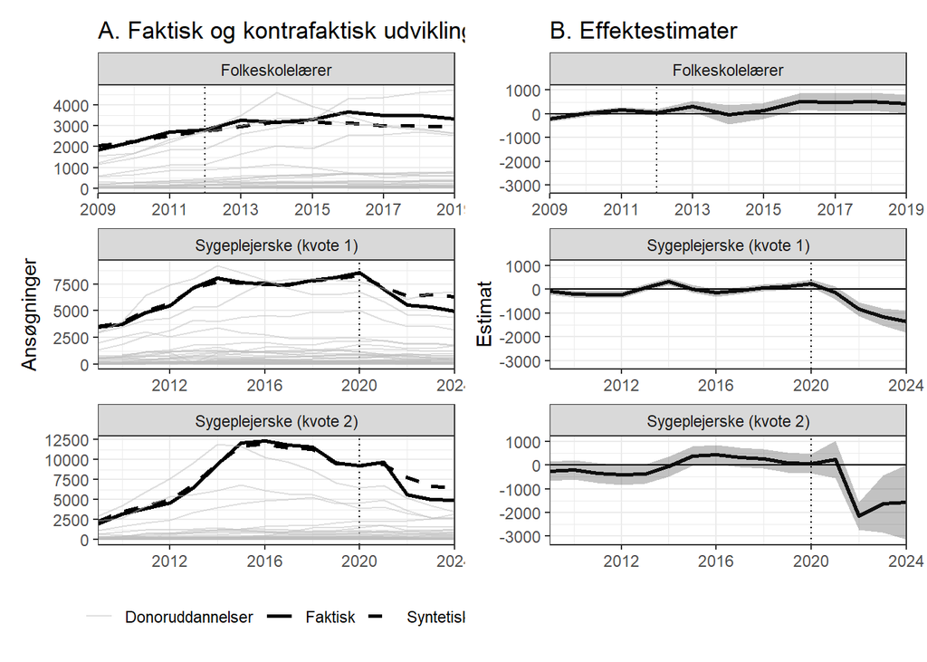

```r
# Laver data frame for lærere
ct_df_lærer <- data.frame(
  uddannelse = "Folkeskolelærer",
  t = as.vector(out_lærer[["time"]]),
  faktisk = as.vector(out_lærer[["Y.tr"]]),
  sk = as.vector(out_lærer[["Y.ct"]]),
  t0 = 2012)

controls_df_lærer <- cbind(ct_df_lærer, out_lærer[["Y.dat"]]) |>
  pivot_longer(cols = -c(uddannelse, t, faktisk, sk, t0),
               names_to = "kontrol_uddannelse",
               values_to = "ansøgere") |>
  filter(kontrol_uddannelse != "Folkeskolelærer")

# Laver data frame for sygeplejersker k1
ct_df_sygeplejersker_k1 <- data.frame(
  uddannelse = "Sygeplejerske (kvote 1)",
  t = as.vector(out_sygeplejersker_k1[["time"]]),
  faktisk = as.vector(out_sygeplejersker_k1[["Y.tr"]]),
  sk = as.vector(out_sygeplejersker_k1[["Y.ct"]]),
  t0 = 2020)

controls_df_sygeplejerske_k1 <- cbind(ct_df_sygeplejersker_k1, out_sygeplejersker_k1[["Y.dat"]]) |>
  pivot_longer(cols = -c(uddannelse, t, faktisk, sk, t0),
               names_to = "kontrol_uddannelse",
               values_to = "ansøgere") |>
  filter(kontrol_uddannelse != "Sygeplejerske (kvote 1)")

# Laver data frame for sygeplejersker k2
ct_df_sygeplejersker_k2 <- data.frame(
  uddannelse = "Sygeplejerske (kvote 2)",
  t = as.vector(out_sygeplejersker_k2[["time"]]),
  faktisk = as.vector(out_sygeplejersker_k2[["Y.tr"]]),
  sk = as.vector(out_sygeplejersker_k2[["Y.ct"]]),
  t0 = 2020)

controls_df_sygeplejerske_k2 <- cbind(ct_df_sygeplejersker_k2, out_sygeplejersker_k2[["Y.dat"]]) |>
  pivot_longer(cols = -c(uddannelse, t, faktisk, sk, t0),
               names_to = "kontrol_uddannelse",
               values_to = "ansøgere") |>
  filter(kontrol_uddannelse != "Sygeplejerske (kvote 2)")

# Samler til 1 data frame
ct_df <- rbind(
  ct_df_lærer[ct_df_lærer$t <= 2019,],
  ct_df_sygeplejersker_k1,
  ct_df_sygeplejersker_k2
)

controls_df <- rbind(
  controls_df_lærer[controls_df_lærer$t <= 2019,],
  controls_df_sygeplejerske_k1,
  controls_df_sygeplejerske_k2) |>
  filter(ansøgere > 0)

# Laver plot
ct_plots <- ct_df |>
  ggplot(aes(y = faktisk, x = t)) +
  geom_line(
    aes(linetype = "Faktisk"),
    color = "black",
    linewidth = 1) +
  geom_line(
    aes(y = sk, linetype = "Syntetisk"),
    linewidth = 1) +
  geom_vline(aes(xintercept = t0), linetype = "dotted") +
  geom_line(
    data = controls_df,
    aes(x = t, y = ansøgere, group = kontrol_uddannelse, linetype = "Donoruddannelser"),
    inherit.aes = FALSE,
    color = "grey",
    alpha = 0.5) +
  scale_linetype_manual(
    values = c(
      "Faktisk" = "solid",
      "Syntetisk" = "dashed",
      "Donoruddannelser" = "solid")) +
  scale_x_continuous(expand = c(0, 0)) +
  facet_wrap(~uddannelse, scales = "free", ncol = 1) +
  theme_bw() +
  theme(legend.position = "bottom") +
  labs(
    x = NULL,
    y = "Ansøgninger",
    linetype = NULL) +
  ggtitle("A. Faktisk og kontrafaktisk udvikling")

# Making gap data frames
# Bemærk: Pre-treatment konfidensintervaller beregnes pba. MSPE i CV.
# Man får dermed at den beregnes som sqrt(MSPE / N_pre)
gap_lærer <- ct_df_lærer |>
  mutate(estimate = faktisk - sk) |>
  bind_cols(as.data.frame(out_lærer[["est.att"]])) |>
  mutate(
    CI.lower = if_else(
      n.Treated == 0,
      estimate - 1.96 * sqrt(out_lærer[["MSPE"]] / sum(as.vector(out_lærer[["est.att"]][,"n.Treated"]) == 0)),
      CI.lower),
    CI.upper = if_else(
      n.Treated == 0,
      estimate + 1.96 * sqrt(out_lærer[["MSPE"]] / sum(as.vector(out_lærer[["est.att"]][,"n.Treated"]) == 0)),
      CI.upper))

gap_sygeplejersker_k1 <- ct_df_sygeplejersker_k1 |>
  mutate(estimate = faktisk - sk) |>
  bind_cols(as.data.frame(out_sygeplejersker_k1[["est.att"]])) |>
  mutate(
    CI.lower = if_else(
      n.Treated == 0,
      estimate - 1.96 * sqrt(out_sygeplejersker_k1[["MSPE"]] / sum(as.vector(out_sygeplejersker_k1[["est.att"]][,"n.Treated"]) == 0)),
      CI.lower),
    CI.upper = if_else(
      n.Treated == 0,
      estimate + 1.96 * sqrt(out_sygeplejersker_k1[["MSPE"]] / sum(as.vector(out_sygeplejersker_k1[["est.att"]][,"n.Treated"]) == 0)),
      CI.upper))

gap_sygeplejersker_k2 <- ct_df_sygeplejersker_k2 |>
  mutate(estimate = faktisk - sk) |>
  bind_cols(as.data.frame(out_sygeplejersker_k2[["est.att"]])) |>
  mutate(
    CI.lower = if_else(
      n.Treated == 0,
      estimate - 1.96 * sqrt(out_sygeplejersker_k2[["MSPE"]] / sum(as.vector(out_sygeplejersker_k2[["est.att"]][,"n.Treated"]) == 0)),
      CI.lower),
    CI.upper = if_else(
      n.Treated == 0,
      estimate + 1.96 * sqrt(out_sygeplejersker_k2[["MSPE"]] / sum(as.vector(out_sygeplejersker_k2[["est.att"]][,"n.Treated"]) == 0)),
      CI.upper))

gap_df <- rbind(
  gap_lærer[gap_lærer$t <= 2019,],
  gap_sygeplejersker_k1,
  gap_sygeplejersker_k2
)

gap_plots <- ggplot(gap_df, aes(x = t, y = estimate)) +
  geom_line(color = "black", linewidth = 1) +
  geom_ribbon(aes(ymin = CI.lower, ymax = CI.upper), alpha = 0.3) +
  geom_hline(yintercept = 0) +
  geom_vline(aes(xintercept = t0), linetype = "dotted") +
  facet_wrap(~uddannelse, ncol = 1, scales = "free_x") +
  scale_x_continuous(expand = c(0, 0)) +
  theme_bw() +
  labs(x = NULL,
       y = "Estimat") +
  ggtitle("B. Effektestimater")

ct_plots | gap_plots
```

**In-place placebos**

**Lærere**

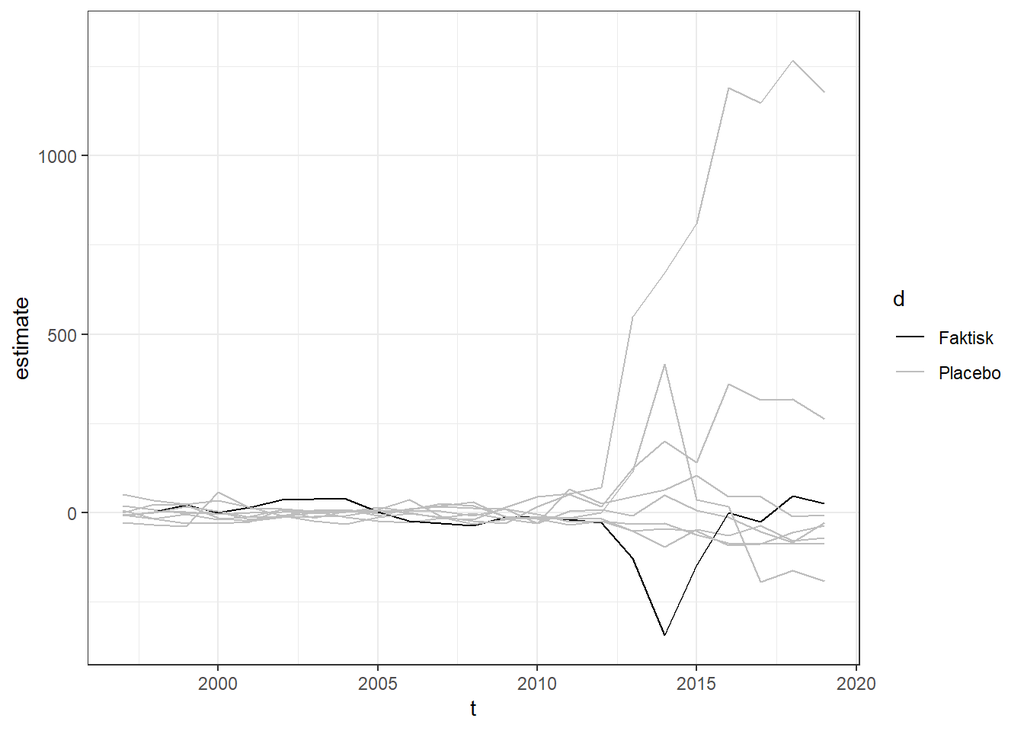

```r
place_placebos_lærer |>
  mutate(estimate = faktisk - sk,
         d = if_else(
           uddannelse == "Folkeskolelærer",
           "Faktisk",
           "Placebo")) |>
  ggplot(aes(x = t, y = estimate, group = uddannelse, color = d)) +
  geom_line() +
  xlim(c(1997, 2019)) +
  scale_color_manual(
    values = c(
      "Placebo" = "grey",
      "Faktisk" = "black")) +
  theme_bw()
```

**Sygeplejersker**

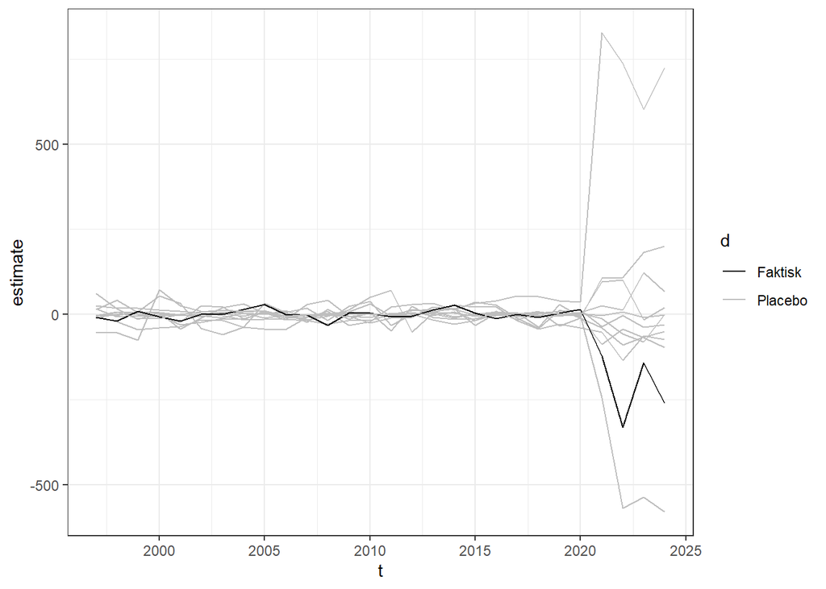

```r
place_placebos_sygeplejersker |>
  ggplot(aes(x = t, y = estimate, group = uddannelse, color = d)) +
  geom_line() +
  xlim(c(1997, 2024)) +
  scale_color_manual(
    values = c(
      "Placebo" = "grey",
      "Faktisk" = "black")) +
  theme_bw()
```